# Ch. 2 Cartesian Tensors — fluidpy

#### ✏️ Tiny example: Ex. 2.4 by hand with Γ = 1 s⁻¹

1. $\mathbf S = \begin{bmatrix}0 & 1\\ 1 & 0\end{bmatrix}$.
2. $\det\begin{bmatrix}-\lambda & 1\\ 1 & -\lambda\end{bmatrix} = \lambda^2 - 1 = 0 \Rightarrow \lambda^1 = 1, \lambda^2 = -1$ (Vieta: sum 0 = trace ✓, product −1 = det ✓).
3. Eigenvector for λ = 1: the first row of $(\mathbf S - \lambda\mathbf I)\cdot\mathbf b = 0$ gives $-b_1 + b_2 = 0 \Rightarrow b_1 = b_2$; normalise $b_1^2 + b_2^2 = 1 \Rightarrow \mathbf b^1 = (1, 1)/\sqrt2$.
4. For λ = −1: $b_1 + b_2 = 0 \Rightarrow \mathbf b^2 = (-1, 1)/\sqrt2$ (sign chosen so that $\det[\mathbf b^1\, \mathbf b^2] = +1$: a 45° rotation, not a mirror).
5. $\mathbf C = \tfrac1{\sqrt2}\begin{bmatrix}1 & -1\\ 1 & 1\end{bmatrix}$ — C02's 2-D matrix with θ = 45° ✓.
6. $S'_{12} = C_{i1}C_{j2}S_{ij} = C_{11}C_{22}S_{12} + C_{21}C_{12}S_{21} = \tfrac12 - \tfrac12 = 0$; $S'_{11} = 2C_{11}C_{21}S_{12} = 1$; $S'_{22} = 2C_{12}C_{22}S_{12} = -1$: $\mathbf S' = \mathrm{diag}(1, -1)$ ✓.
7. Bounds: on the 30° plane $\mathbf n\cdot\mathbf S\cdot\mathbf n = \sin60° = 0.866 \in [-1, 1]$ ✓; max shear $(1 - (-1))/2 = 1$, reached at φ = 0° and 90° (the original axes, where S has only shear) ✓.

```python
res = ch02.example_2_4(1.0)                                          # Ex. 2.4 packaged: Γ = S₁₂ = 1 s⁻¹, the book's order (Γ, −Γ), b¹ first
print(res["lam"], np.round(res["B"], 4), np.round(np.rad2deg(res["angle_rad"]), 1))   # [1 −1], columns (1,1)/√2 and (−1,1)/√2, 45.0°
print(np.round(res["S_prime"], 12))                                  # diag(1, −1): no shear in the principal axes
lam, Bm = ch02.principal_axes(A)                                     # C07's 3×3 example: λ ascending, unit eigenvectors as columns, det +1
print(np.round(lam, 4), np.round(np.linalg.det(Bm), 12))             # [1.2679 3. 4.7321] 1.0
Cp, tp = ch02.diagonalize(A)                                         # (C, τ' = CᵀτC) — fact 3
print(np.round(tp, 10))                                              # diag(1.2679, 3, 4.7321)
print(np.round(np.roots(ch02.characteristic_polynomial(A)), 4))      # the same three λ from the cubic (D18): they are invariants
n_mc = 1000 if not FAST else 300                                     # random unit normals (FAST: 300)
print(ch02.normal_stress_bounds(A, np.random.default_rng(6), n=n_mc))   # (min σ_n, max σ_n, max τ_s) over random planes: inside [1.27, 4.73], shear ≤ 1.73
print(ch02.principal_angle_2d([[0., 1.], [1., 0.]]))                 # 0.7854 rad = 45°: the 2-D shortcut
try:                                                                 # a non-symmetric input …
    ch02.principal_axes([[0., 1.], [0., 0.]])
except ValueError as e:                                              # … is refused on purpose: facts (1)–(4) do not hold for it
    print("refused:", e)
```

```
[ 1. -1.] [[ 0.7071 -0.7071]
 [ 0.7071  0.7071]] 45.0
[[ 1.  0.]
 [ 0. -1.]]
[1.2679 3.     4.7321] 1.0
[[ 1.2679 -0.     -0.    ]
 [-0.      3.     -0.    ]
 [-0.     -0.      4.7321]]
[4.7321 3.     1.2679]
(1.2784045616114288, 4.730922823029971, 1.7316136866990928)
0.7853981633974483
refused: principal_axes needs a real symmetric tensor (§2.11 facts (1)–(4) fail otherwise)
```

**What does the code above do?**

1. `example_2_4` returns the book's numbers: λ = (Γ, −Γ), the 45° axes, S' = diag(1, −1).
2. `principal_axes` on C07's 3×3 example: three real eigenvalues, an orthonormal C with det +1.
3. `diagonalize` shows fact 3: $\mathbf C^{\rm T}\mathbf A\mathbf C$ is diagonal.
4. The roots of D18's characteristic polynomial are the same λ — eigenvalues are invariants.
5. `normal_stress_bounds` tries 1000 random planes: no normal stress leaves [λ_min, λ_max] and no shear exceeds (λ_max − λ_min)/2 = 1.732 (fact 4).
6. The 2-D principal angle by the `arctan2` shortcut (P70).
7. Non-symmetric input is refused — the library raises on purpose (a `try/except ValueError` catches the message).

```python
S2 = np.array([[0., 1.], [1., 0.]])                                              # Ex. 2.4's S
tr, det = S2.trace(), np.linalg.det(S2)                                          # I₁ = 0 and I₂ = det = −1 (2-D invariants, D18)
lam_mine = np.array([(tr + np.sqrt(tr**2 - 4 * det)) / 2, (tr - np.sqrt(tr**2 - 4 * det)) / 2])   # the quadratic formula for λ² − I₁λ + I₂ = 0
b1 = np.array([S2[0, 1], lam_mine[0] - S2[0, 0]]); b1 /= np.linalg.norm(b1)       # eigenvector from the first row of (S − λI)b = 0, normalised (P67)
b2 = np.array([-b1[1], b1[0]])                                                   # the perpendicular unit vector (det [b¹ b²] = +1)
assert np.allclose(lam_mine, res["lam"])                                         # (1, −1)
assert np.allclose(abs(b1 @ res["B"][:, 0]), 1)                                  # the same first axis (up to sign)
assert np.allclose(np.c_[b1, b2].T @ S2 @ np.c_[b1, b2], np.diag(lam_mine))      # CᵀSC = diag(λ): fact 3 by hand (np.c_ stacks columns)
print("quadratic formula + first row of (S − λI)b = 0 reproduce example_2_4")
```

```
quadratic formula + first row of (S − λI)b = 0 reproduce example_2_4
```

```python
def strain_axes(Gamma):                                                       # one slider position: S = [[0, Γ], [Γ, 0]]
    S_ = np.array([[0., Gamma], [Gamma, 0.]])                                 # the strain rate [1/s]
    ex = ch02.example_2_4(Gamma)                                              # its principal axes and values
    t_ = 0.5                                                                  # a fixed deformation time [s]
    sq_0 = ch02.deform_square(S_, 0.0, 30, half_width=0.7, boundary_only=True)   # the square outline at t = 0
    sq_t = ch02.deform_square(S_, t_, 30, half_width=0.7, boundary_only=True)    # … after stretching along b¹ by e^{Γt}, squeezing along b² by e^{−Γt}
    b1_, b2_ = ex["B"][:, 0], ex["B"][:, 1]                                   # the eigen-axes
    return {"square at t = 0": (sq_0[0], sq_0[1]),
            "square under S at t = 0.5 s": (sq_t[0], sq_t[1]),
            "b¹ (stretch, λ¹ = +Γ)": ([0, ex["lam"][0] * b1_[0]], [0, ex["lam"][0] * b1_[1]]),    # arrow of length λ¹ along b¹
            "b² (squeeze, λ² = −Γ)": ([0, -ex["lam"][1] * b2_[0]], [0, -ex["lam"][1] * b2_[1]])}  # arrow of length |λ²| along b²
fig = slider_figure(strain_axes, "Γ", np.linspace(0.2, 3.0, 30 if not FAST else 15), unit="1/s", xlabel="x₁ [m]", ylabel="x₂ [m]",
                    title="Ex. 2.4: the principal axes stay at 45°; only the stretch (and λ = ±Γ) grows with Γ",
                    xrange=[-3.3, 3.3], yrange=[-3.3, 3.3], height=520, active=8)
fig.update_yaxes(scaleanchor="x", scaleratio=1)                               # equal axes
fig.show()
```

[interactive chart not shown]

**What does the code above do?**

1. For each Γ the strain rate S = [[0, Γ], [Γ, 0]] is diagonalised by `example_2_4`; the two arrows are the eigen-axes scaled by |λ| = Γ.
2. A square of material points is deformed by S alone for 0.5 s (`deform_square`, P79): it stretches along b¹ by $e^{\Gamma t}$ and squeezes along b² by $e^{-\Gamma t}$, never shearing those two axes.

**What you see.** A square, its stretched-and-squeezed image, and two arrows at ±45° whose length grows with Γ; the arrows' directions never move.

**How to read it.** The principal *directions* depend on the shape of S (here always pure shear → 45°), the eigenvalues on its size (±Γ).

**What would change if…** …you added $S_{11} = 1$: the angle drops below 45° (`ch02.principal_angle_2d([[1, Γ], [Γ, 0]])`) and Mohr's centre moves right by ½.

🔁 *Reminder (Ch. 1 primer P47):* `live(fn, a=(lo, hi, step))` builds ipywidgets sliders that re-run `fn` while a kernel runs; the published page freezes it, so the slider figure above carries the idea there.

> ▶️ **Live cell.** The widget below needs a running Python kernel. On the web page it is frozen — open this notebook in Colab (button at the top) or run it locally to drag the sliders.

```python
from fluidpy.core.interact import live                                              # ipywidgets sliders (kernel only, Ch. 1 P47)
def principal_plot(S11=0.0, S22=0.0, S12=1.0):                                      # called again whenever a slider is released
    S_ = np.array([[S11, S12], [S12, S22]])                                         # a symmetric 2×2 [1/s or Pa]
    lam_, B_ = ch02.principal_axes(S_)                                              # eigenvalues (ascending) and unit eigenvectors as columns
    ang_ = np.rad2deg(ch02.principal_angle_2d(S_))                                  # the first principal angle [°]
    c_, r_ = ch02.mohr_circle_2d(S_)                                                # Mohr's circle
    fig, (a1, a2) = plt.subplots(1, 2, figsize=(9, 4))                              # element + axes | Mohr circle
    sq_ = ch02.deform_square(S_, 0.4, 30, half_width=0.7, boundary_only=True)      # the element after 0.4 s under S
    a1.plot(*ch02.deform_square(S_, 0.0, 30, half_width=0.7, boundary_only=True), "--", color=COLORS["muted"]); a1.plot(*sq_, color=COLORS["accent"])
    for k, col in ((0, COLORS["rose"]), (1, COLORS["blue"])):                       # eigen-axes: smallest λ rose, largest blue
        a1.annotate("", 1.3 * B_[:, k], -1.3 * B_[:, k], arrowprops=dict(arrowstyle="<->", color=col, lw=2))
    a1.set_xlim(-2.5, 2.5); a1.set_ylim(-2.5, 2.5); a1.set_aspect("equal"); a1.set_title(f"λ = ({lam_[0]:.2f}, {lam_[1]:.2f}), first axis at {ang_:.1f}°", fontsize=9)
    th_ = np.linspace(0, 2 * np.pi, 181); a2.plot(c_ + r_ * np.cos(th_), r_ * np.sin(th_), color=COLORS["accent"])   # the circle
    a2.plot(lam_, [0, 0], "o", color=COLORS["ink"]); a2.axhline(0, color=COLORS["muted"], lw=0.8); a2.set_aspect("equal")
    a2.set_xlabel("σ_n"); a2.set_ylabel("τ_s"); a2.set_title(f"Mohr: centre {c_:.2f}, radius {r_:.2f} (max shear)", fontsize=9)
    plt.show()                                                                      # draw for these slider values
_ = live(principal_plot, S11=(-2.0, 2.0, 0.1), S22=(-2.0, 2.0, 0.1), S12=(-2.0, 2.0, 0.1))   # three sliders (_ hides the widget's return value)
```

▶️ **Live cell.** These sliders need a running Python kernel, so they are frozen on this page. Press **Open in Colab** at the top (or run the notebook locally) to use them.

**What does the code above do?**

1. The callback diagonalises the symmetric 2×2 you set with the sliders, draws the deformed element with its eigen-axes, and Mohr's circle with the two principal values on the σ axis.
2. Set S₁₂ = 0: the axes align with x₁, x₂. Set S₁₁ = S₂₂ and S₁₂ = 0: the circle shrinks to a point — every plane is principal (the hydrostatic case).

**What would change if…** τ were not symmetric? Complex eigenvalues and skewed eigenvectors are possible and the bounds fail — which is why `principal_axes` refuses, and why Ch. 4's proof that the stress *is* symmetric matters.

## 2.12 Gauss' Theorem

**What is this section about?** A derivative integrated over a volume equals the field itself integrated over the boundary with the outward normal — for a field of any order. Read backwards on a tiny box it *defines* the divergence as outflux per unit volume, and the Cartesian formula $\nabla\cdot\mathbf u = \partial u_i/\partial x_i$ (2.23) falls out face by face.

### 🧩 Gauss' theorem: derivative inside = normal outside `C14`

*The question:* Why does adding up $\partial Q/\partial x_i$ over a whole volume only depend on what Q does on the surface?

#### The problem in plain words

Ch. 4 will write conservation laws for a blob of fluid: the mass inside changes only by what flows through its skin; the momentum inside changes by the forces on its skin (C05!). Turning "inside" into "on the skin" — and back — is Gauss' theorem. Without it there is no differential form of any conservation law.

#### The idea

```
1-D:  ∫_a^b f'(x) dx = f(b) − f(a)                 (fundamental theorem: the inside adds up to the two ends)
3-D:  ∭_V ∂Q/∂x_i dV = ∯_A n_i Q dA                 (the ends become the boundary, with n_i = ±1 on two faces of a box)
any V:  tile it with boxes — every interior face is counted twice with opposite n and cancels
```

> 📎 **Primer — volume and surface integrals as midpoint sums.** `P83` · $\iiint_V f\,dV$ adds f × (small volume) over a 3-D grid of cells; the midpoint rule uses f at each cell centre (error ∝ h²). A surface integral $\iint_A g\,dA$ does the same on a 2-D grid of the surface. Iterated integrals: integrate in x first, then y, then z. (🔁 Ch. 1 P27 defined the definite integral, P37 the trapezoid rule; the midpoint rule is its sibling.) For a *linear* integrand the midpoint rule is exact — the fact D22 leans on.

```python
n = 20; xs = (np.arange(n) + 0.5) / n                      # cell centres on [0, 1]
X, Y, Z = np.meshgrid(xs, xs, xs, indexing='ij')           # a 20³ grid of cell centres
print(np.sum(X**2) / n**3)                                 # ∭ x² dV over the unit cube = 1/3 (0.3331 with n = 20 — the midpoint rule undershoots a convex integrand by ∝ 1/n²)
print(np.sum(X[:, :, 0]**2) / n**2)                        # ∬ x² dA over the unit square = 1/3
```

```
0.333125
0.333125
```

> 📎 **Primer — fundamental theorem of calculus.** `P84` · $\int_a^b f'(x)\,dx = f(b) - f(a)$: integrating a derivative gives the change of the function between the ends (🔁 Ch. 1 P27 defined the integral; this is its partner). It is the whole content of Gauss' theorem in one dimension.

```python
f = lambda x: x**3                                         # a function
xs = np.linspace(0, 2, 2001)                               # a fine grid on [0, 2]
print(np.trapezoid(3 * xs**2, xs), f(2) - f(0))            # 8.000 8: ∫ f' dx = f(2) − f(0)  (trapezoid rule, Ch. 1 P37)
```

```
8.000001 8
```

#### The maths, step by step

1. **Statement (2.30):** $\iiint_V \partial Q/\partial x_i\,dV = \iint_A n_i Q\,dA$ for Q of any order (scalar, vector, tensor — the other indices ride along), n outward.
2. For a vector, set Q → $Q_i$ and sum on i (allowed: (2.30) is linear in Q; N64): $\iiint_V \nabla\cdot\mathbf Q\,dV = \iint_A \mathbf n\cdot\mathbf Q\,dA$ — the **divergence theorem**: volume integral of the divergence = net outflux.
3. **Proof (D25):** on a box by the fundamental theorem of calculus along one axis; on any V by tiling and cancelling interior faces.

#### 🧮 Derivation — Gauss' theorem, from the fundamental theorem of calculus (Eq. 2.30)

**What we want to show.** Prove the theorem the book only states: the volume integral of a derivative equals the surface integral of the field with the outward normal — first for a box, then for any volume by tiling.

**Assumptions.** Q continuously differentiable on V and its boundary (steps 2, 9) · the boundary A piecewise smooth, so that the tiling's outer faces approach it (step 9).

**The plan.**

1. On a box, write the volume integral of ∂Q/∂x₁ as an iterated integral and do the x₁ integral first.
2. Read the right side of $\iiint_V \partial Q/\partial x_i\,dV = \iint_A n_iQ\,dA$ (2.30) face by face: n₁ = ±1 on two faces, 0 on four.
3. Repeat for i = 2, 3.
4. Tile a general volume with boxes; interior faces cancel.

**Tools we use** (each explained before this point): fundamental theorem of calculus (P84) · iterated integrals (P83) · outward normals of a box (C04's faces) · additivity of integrals over disjoint regions (step 7) · vector area / opposite normals (P69; step 8)

**We start from**

$$ \int_a^b f'(x)\,dx = f(b) - f(a) $$

*In words:* the fundamental theorem of calculus (P84): integrating a derivative gives the values at the two ends.

**Step 1 of 9 — Write the i = 1 volume integral on a box as iterated integrals.**

$$ \iiint_V \frac{\partial Q}{\partial x_1}\,dV = \int_{a_3}^{b_3}\!\int_{a_2}^{b_2}\Big[\int_{a_1}^{b_1}\frac{\partial Q}{\partial x_1}\,dx_1\Big]dx_2\,dx_3 $$

- *Why we can do this:* On a box $[a_1, b_1]\times[a_2, b_2]\times[a_3, b_3]$ a volume integral is three nested one-dimensional integrals in any order; we do x₁ innermost because the derivative is in x₁.
- *In words:* Integrate along x₁ first, on every line of the box.

**Step 2 of 9 — Apply the fundamental theorem to the inner integral.**

$$ \int_{a_1}^{b_1}\frac{\partial Q}{\partial x_1}\,dx_1 = Q(b_1, x_2, x_3) - Q(a_1, x_2, x_3) $$

- *Why we can do this:* Along a line with x₂, x₃ fixed, ∂Q/∂x₁ is an ordinary derivative of a function of x₁; the fundamental theorem gives the two end values (Q ∈ C¹).
- *In words:* Each line contributes Q at its far end minus Q at its near end.

**Step 3 of 9 — Insert and split into two face integrals.**

$$ \iiint_V \frac{\partial Q}{\partial x_1}\,dV = \iint Q(b_1, x_2, x_3)\,dx_2dx_3 - \iint Q(a_1, x_2, x_3)\,dx_2dx_3 $$

- *Why we can do this:* Step 2 into step 1; the remaining double integrals run over the face $[a_2, b_2]\times[a_3, b_3]$ — the two faces perpendicular to x₁.
- *In words:* The inside adds up to "Q on the far face minus Q on the near face".

**Step 4 of 9 — Read the right side of (2.30) face by face.**

$$ n_1 = +1\ \text{on}\ x_1 = b_1,\quad n_1 = -1\ \text{on}\ x_1 = a_1,\quad n_1 = 0\ \text{on the other four faces} $$

- *Why we can do this:* The outward normal of a box face is ±e_i; its first component is nonzero only on the two faces perpendicular to x₁. Four of the six faces contribute nothing to the i = 1 term.
- *In words:* Only the two faces facing ±x₁ count for the x₁-derivative.

**Step 5 of 9 — Conclude (2.30) for i = 1 on the box.**

$$ \iint_A n_1Q\,dA = \iint Q(b_1,\cdot)\,dA - \iint Q(a_1,\cdot)\,dA = \iiint_V\frac{\partial Q}{\partial x_1}\,dV $$

- *Why we can do this:* Step 4 makes the surface integral exactly the two face integrals of step 3 with the signs of n₁. Left and right sides of (2.30) coincide for i = 1.
- *In words:* Gauss' theorem holds for the x₁-derivative on a box.

**Step 6 of 9 — Repeat for i = 2 and i = 3.**

$$ \iiint_V\frac{\partial Q}{\partial x_i}\,dV = \iint_A n_iQ\,dA\quad\text{on any box, } i = 1, 2, 3 $$

- *Why we can do this:* Steps 1–5 with the roles of the axes relabelled (integrate along x_i first; the faces ⊥ x_i carry n_i = ±1). Nothing used which axis was first.
- *In words:* The same for each of the three directions.

**Step 7 of 9 — Tile a general volume with small boxes and add.**

$$ \sum_k\iiint_{V_k}\frac{\partial Q}{\partial x_i}\,dV = \sum_k\iint_{A_k} n_iQ\,dA,\qquad \sum_k\iiint_{V_k} = \iiint_{V_{\rm tiles}} $$

- *Why we can do this:* Step 6 holds on each box V_k; adding the equations adds both sides. Integrals over disjoint regions add up to the integral over their union.
- *In words:* Gauss on every tile, summed.

**Step 8 of 9 — Cancel the interior faces.**

$$ \sum_k\iint_{A_k} n_iQ\,dA = \iint_{\text{outer faces}} n_iQ\,dA $$

- *Why we can do this:* A face shared by two tiles appears twice with opposite outward normals (n and −n) and the same values of Q (continuity), so the two contributions sum to zero. Only faces on the outside of the tiling survive.
- *In words:* Every inner wall is counted once from each side and cancels.

**Step 9 of 9 — Refine the tiling.**

$$ \iiint_V\frac{\partial Q}{\partial x_i}\,dV = \iint_A n_iQ\,dA $$

- *Why we can do this:* As the boxes shrink, the tiled region fills V and its staircase boundary tends to A with the outer normals tending to n (A piecewise smooth, Q continuous), so both sides converge to the integrals over V and A. Q may carry any other indices: nothing depended on its order.
- *In words:* Gauss' theorem for any volume and any field.

**Result**

$$ \iiint_V\frac{\partial Q}{\partial x_i}\,dV = \iint_A n_iQ\,dA \quad\text{for Q of any order} $$

*In words:* a derivative integrated over the inside equals the field weighted by the outward normal on the boundary.

**What it means.** Every conservation law of Ch. 4 passes through this line: the rate of change of what is inside a volume equals the flux through its boundary, and shrinking the volume (D21) turns the integral law into a partial differential equation. The theorem needs Q differentiable *inside* — a point source or a shock breaks it and adds a surface term.

**Check it.** Units: [Q]·m² both sides ✓. Limit Q constant: left 0; right ∮ n_i dA = 0 (vector area of a closed surface, P69) ✓. Number: Q = (x, y, z) on the unit cube: ∭ 3 dV = 3; faces +1 + 0 + 1 + 0 + 1 + 0 = 3 ✓ (`divergence_theorem_box` below); sphere benchmark F = (2x, y², z²): 8π/3 both sides (`divergence_theorem_sphere`); `divergence_theorem_tiled` reports interior faces summing to 0 to round-off.

> ⚠️ **Common confusion (traps in this derivation):** thinking all six faces contribute to each i. Cancelling interior faces without opposite normals and equal Q. Forgetting that the tiles' boundary is only an approximation of A until the limit.

📝 **Note.** **The divergence theorem and the outflux reading** `N64` — $\mathbf n\cdot\mathbf Q\,dA$ is how much Q leaves through dA. Benchmark (the standard divergence-theorem example): $\mathbf F = (2x, y^2, z^2)$ through the unit sphere: $\nabla\cdot\mathbf F = 2 + 2y + 2z$, whose integral over the ball is $2\cdot\tfrac43\pi + 0 + 0 = 8\pi/3 = 8.378$; `ch02.divergence_theorem_sphere` gives both sides. **Fig. 2.9** `N65` is our 3-D box below, faces coloured by n·Q.

$$ \iiint_V \frac{\partial Q_i}{\partial x_i}\,dV = \iint_A n_i Q_i\,dA \quad\text{or}\quad \iiint_V \nabla\cdot\mathbf Q\,dV = \iint_A \mathbf n\cdot\mathbf Q\,dA \qquad \text{(§2.12)} $$

#### ✏️ Tiny example: Q = (x, y, z) on the unit cube [0, 1]³

1. Inside: $\nabla\cdot\mathbf Q = 1 + 1 + 1 = 3$; volume 1 → left side 3.
2. Outside, face by face: on x = 1, n = +e₁, n·Q = x = 1, area 1 → +1; on x = 0, n·Q = −x = 0 → 0; same for y and z → right side 1 + 0 + 1 + 0 + 1 + 0 = 3 ✓.
3. Q = (x², 0, 0): inside $\int_0^1 2x\,dx = 1$; outside +1 (x = 1) + 0 = 1 ✓ — only the two x-faces contribute, as D25 says.

```python
Q = lambda x, y, z: np.stack([x, y, z])                                  # the vector field Q = (x, y, z) as a function of grid arrays (components on axis 0)
lhs, rhs = ch02.divergence_theorem_box(Q, ((0, 1),) * 3, 16)             # both sides of (2.30) on the unit cube by midpoint sums (P83), 16 nodes per side
print(lhs, rhs)                                                          # 3.0 3.0
Q2 = lambda x, y, z: np.stack([x**2, 0 * y, 0 * z])                      # Q = (x², 0, 0)
print(ch02.divergence_theorem_box(Q2, ((0, 1),) * 3, 16))                # (1.0, 1.0): only the two x-faces leak
F = lambda x, y, z: np.stack([2 * x, y**2, z**2])                        # the sphere benchmark field
lhs_s, rhs_s = ch02.divergence_theorem_sphere(F, 1.0, 48 if not FAST else 24)   # ∭ ∇·F dV over the unit ball vs ∯ n·F dA over the sphere
print(lhs_s, rhs_s, 8 * np.pi / 3)                                       # 8.3776 8.3776 8.3776: agree to ~1e-14 — the spherical product rule integrates these low-degree polynomials essentially exactly
print(ch02.gauss_gradient_box(lambda x, y, z: x * y * z, ((0, 1),) * 3, 16))   # (2.30) on a SCALAR: both sides are the vector (¼, ¼, ¼)
Q2d = ch02.radial_field(1.0, dim=2)                                      # the plane field (x, y) for the 2-D pictures
print(ch02.flux_through_faces(Q2d, ((0, 1), (0, 1)), 16))                # {'+x': 1, '-x': 0, '+y': 1, '-y': 0}: the right and top faces leak 1 each
print(ch02.divergence_theorem_tiled(Q2d, ((0, 1), (0, 1)), 4, 16))       # 4×4 tiles: (sum over tiles, outer boundary, interior faces) = (2, 2, 0): D25 step 8 as a number
```

```
3.0000000000000018 3.0
(0.9999999999999982, 1.0)
8.377580409572767 8.377580409572744 8.377580409572781
(array([0.25, 0.25, 0.25]), array([0.25, 0.25, 0.25]))
{'+x': 1.0, '-x': 0.0, '+y': 1.0, '-y': 0.0}
TiledFlux(sum_tiles=2.0, outer=2.0, interior=0.0)
```

**What does the code above do?**

1. `divergence_theorem_box` evaluates both sides of $\iiint_V \partial Q/\partial x_i\,dV = \iint_A n_iQ\,dA$ (2.30) for a vector Q on a box by midpoint sums: 3 = 3.
2. For Q = (x², 0, 0) both sides are 1: only the two x-faces contribute (D25 step 4).
3. The sphere benchmark: both sides equal 8π/3 to ~1e-14 — for these low-degree polynomials the spherical product rule is essentially exact, so no visible quadrature error remains.
4. `gauss_gradient_box` is the scalar form of $\iiint_V \partial Q/\partial x_i\,dV = \iint_A n_iQ\,dA$ (2.30): the volume integral of ∇(xyz) equals the surface integral of n·(xyz) — a vector on both sides.
5. `flux_through_faces` lists the four signed face fluxes of a plane field.
6. `divergence_theorem_tiled` splits the square into 4×4 tiles: the tile boundaries sum to the outer flux and the interior faces cancel to round-off — D25 step 8 made visible.

```python
n = 16; c = (np.arange(n) + 0.5) / n                                    # face-cell centres (midpoint rule, P83)
Ai, Bi = np.meshgrid(c, c, indexing='ij')                               # a 16×16 grid on one face
flux = 0.0                                                              # ∯ n·Q dA from scratch, face by face
for axis in range(3):                                                   # the pair of faces perpendicular to axis
    for side, sgn in ((1.0, +1), (0.0, -1)):                            # far face n = +e_axis, near face n = −e_axis
        coords = [Ai, Bi]; coords.insert(axis, np.full_like(Ai, side))  # the face's points: fixed coordinate = side
        flux += sgn * Q(*coords)[axis].sum() / n**2                     # n·Q = ±Q_axis, times the face area 1/n² per cell
Xc, Yc, Zc = np.meshgrid(c, c, c, indexing='ij')                        # cell centres inside
vol = (3 * np.ones_like(Xc)).sum() / n**3                               # ∭ ∇·Q dV with ∇·Q = 3
assert np.allclose((vol, flux), ch02.divergence_theorem_box(Q, ((0, 1),) * 3, n))   # the library does the same sums
print(vol, flux, "= 3: six face sums by hand")
```

```
3.0 3.0 = 3: six face sums by hand
```

```python
from scripts.ch02_fig2_9_gauss import gauss_box_figure                   # drawing helper (P64): faces coloured by n·Q
fig = gauss_box_figure(F)                                                # F = (2x, y², z²) on the unit cube; the two totals in the title
fig.show()                                                               # rotate: blue = inflow, orange = outflow
```

[interactive chart not shown]

**What does the code above do?**

1. Each face of the unit cube is coloured by the local outflux n·F (blue in, orange out) and labelled with its total.
2. The title compares ∭ ∇·F dV with the sum of the six face fluxes — the two sides of $\iiint_V \partial Q/\partial x_i\,dV = \iint_A n_iQ\,dA$ (2.30).

**What you see.** Orange faces where F leaves (x = 1, y = 1, z = 1), blue or pale where it enters or is tangent; the title's two totals agree.

**How to read it.** The sum of the face colours (weighted by area) equals the integral of the divergence inside — 4 = 4 for this F on the cube.

**What would change if…** …Q = b × x: every face is half blue, half orange, net zero — solenoidal (`gauss_box_figure(lambda x, y, z: np.stack([-y, x, 0*z]))`).

```python
Fs = ch02.smooth_test_field(3)                                           # a sin/cos field with a known exact divergence
exact_vol = ch02.volume_integral_box(Fs.div_fn, ((0, 1),) * 3, 96)       # the exact ∭ ∇·Q dV (very fine grid)
ns_mesh = [4, 6, 8, 12, 16, 24, 32] if not FAST else [4, 8, 16, 32]      # mesh counts per side
def two_sides(n_):                                                       # one slider position: n nodes per direction
    l, r_ = ch02.divergence_theorem_box(Fs, ((0, 1),) * 3, int(n_))      # both sides by midpoint sums
    return {"∭ ∇·Q dV (inside)": ([0, 0], [0, l]), "∯ n·Q dA (boundary)": ([1, 1], [0, r_]),   # two bars
            "exact value": ([-0.5, 1.5], [exact_vol, exact_vol])}         # the reference line
fig = slider_figure(two_sides, "n", ns_mesh, unit="nodes/side", xlabel="", ylabel="value [Q·m²]",
                    title="Both sides are approximations of one number: the gap closes as the mesh refines (∝ 1/n²)",
                    xrange=[-0.5, 1.5], height=420, modes={"∭ ∇·Q dV (inside)": "lines+markers", "∯ n·Q dA (boundary)": "lines+markers"})
fig.update_xaxes(tickvals=[0, 1], ticktext=["inside", "boundary"]); fig.show()
gaps = [abs(np.subtract(*ch02.divergence_theorem_box(Fs, ((0, 1),) * 3, n_))) for n_ in ns_mesh]   # |lhs − rhs| per mesh
print({n_: f"{gp:.1e}" for n_, gp in zip(ns_mesh, gaps)})              # the gap falls by about 4 per doubling of n
```

[interactive chart not shown]

```
{4: '1.3e-03', 6: '5.8e-04', 8: '3.2e-04', 12: '1.4e-04', 16: '8.1e-05', 24: '3.6e-05', 32: '2.0e-05'}
```

**What does the code above do?**

1. For the smooth sin/cos field the two sides of $\iiint_V \partial Q/\partial x_i\,dV = \iint_A n_iQ\,dA$ (2.30) are computed by midpoint sums with n nodes per side.
2. Two "bars" (vertical lines) and the exact value; the printed gaps shrink by ≈ 4 per doubling — both sides are second-order approximations of one number.

**What you see.** Two bars of almost equal height and a dashed exact line; dragging n up brings the bars onto the line.

**How to read it.** The two bars meet as the mesh refines; the printed gap falls by about 4 per doubling of n.

**What would change if…** …Q were a polynomial of degree ≤ 2: the gap would be 1e-16 at every n (midpoint sums are exact for quadratics on each face).

#### 🎮 Interactive: What leaks out of a box?

The theorem has a left side that lives inside and a right side on the boundary; moving and resizing a box over a field, watching the face fluxes re-sum to the integrated divergence, tiling it to see interior faces cancel, and shrinking it until (1/V)∮ settles on ∇·Q is the whole chain from $\iiint_V \partial Q/\partial x_i\,dV = \iint_A n_iQ\,dA$ (2.30) to $\nabla\cdot\mathbf Q = \lim_{V\to0}\frac1V\iint_A\mathbf n\cdot\mathbf Q\,dA$ (2.32) as an experiment.

**What to try:**

- Drag the box over the source: the total bar turns orange.
- Tile 4×4: interior arrows appear in opposite pairs and cancel — D25 step 8.
- Shrink h on the log slider and watch (1/V)∮ approach the dashed ∇·Q(x₀) with slope 2.
- b × x preset: every box, anywhere, has zero net flux.

```python
show_viz("ch02", "gauss_flux_box")   # full-width explainer; ⤢ Full screen for more room
```

🎮 Interactive 5/5 What leaks out of a box? Open alone ↗

[interactive chart not shown]

**What would change if…** the volume shrank to a point? Divide both sides by V and take the limit: the right side becomes "outflux per unit volume" — a definition of the divergence that never mentions coordinates. C15.

### 🧩 Divergence as outflux per unit volume: the integral definitions `C15`

*The question:* Can $\nabla\cdot\mathbf Q$ be defined without any coordinates at all — and how does the formula $\partial Q_i/\partial x_i$ come back out?

#### The problem in plain words

The Cartesian formula $\nabla\cdot\mathbf u = \partial u_i/\partial x_i$ (2.23) is a recipe, not a meaning. The meaning is: put a tiny closed surface around the point, measure what leaks out, divide by the volume. That definition works in spherical coordinates on a planet as well as on a Cartesian grid, and it is exactly the box argument Ch. 4 uses to derive the continuity equation.

#### The idea

Gauss' theorem $\iiint_V \partial Q/\partial x_i\,dV = \iint_A n_iQ\,dA$ (2.30), read on a tiny box, becomes the outflux definition $\nabla\cdot\mathbf Q = \lim_{V\to0}\frac1V\iint_A\mathbf n\cdot\mathbf Q\,dA$ (2.32):

```
(2.30) on a tiny box around x₀:  (1/V) ∯ n·Q dA  →  ∇·Q(x₀)  as V → 0          (2.32)
face by face (Ex. 2.5):  Q on the +e₁ face ≈ Q + (Δx₁/2) ∂Q/∂x₁ ;  on the −e₁ face ≈ Q − (Δx₁/2) ∂Q/∂x₁
                         opposite faces: the Q's cancel, the slopes add  →  ∂Q₁/∂x₁ Δx₁Δx₂Δx₃ ;  divide by V
```

> 📎 **Primer — mean-value theorem for integrals.** `P85` · If f is continuous on a region V, then $\iiint_V f\,dV = f(\mathbf x^*)\,V$ for some point x* inside V: the integral equals the volume times some intermediate value of f. As V shrinks to a point x₀, x* is squeezed onto x₀.

```python
xs = np.linspace(0.9, 1.1, 2001)                          # a small interval around 1
f = xs**2                                                 # f = x²
mean = np.trapezoid(f, xs) / 0.2                          # the integral divided by the length = f(x*) for some x* (Ch. 1 P37)
print(mean, np.sqrt(mean))                                # 1.0033, and x* = 1.0017 lies inside [0.9, 1.1]
```

```
1.0033333350000002 1.0016652809197293
```

#### The maths, step by step

1. (2.31) $\mathcal DQ = \lim_{V\to0}(1/V)\iint_A n_iQ\,dA$ — the generalised derivative (gradient of any order), from $\iiint_V \partial Q/\partial x_i\,dV = \iint_A n_iQ\,dA$ (2.30) by the mean-value theorem (D21).
2. Contract: (2.32) $\nabla\cdot\mathbf Q = \lim (1/V)\iint \mathbf n\cdot\mathbf Q\,dA$; cross: (2.33) $\nabla\times \mathbf Q = \lim (1/V)\iint \mathbf n\times\mathbf Q\,dA$.
3. Ex. 2.5 (D22): evaluate (2.32) on a box — Taylor to the six face centres, opposite faces cancel the zeroth order, divide by the volume, take the limit: $\nabla\cdot\mathbf Q = \partial Q_i/\partial x_i$ (2.23) returns.

#### 🧮 Derivation — The integral definitions as small-volume limits of Gauss' theorem (Eq. 2.31–2.33)

**What we want to show.** Turn Gauss' theorem, read on a shrinking volume, into coordinate-free definitions of the gradient, the divergence and the curl — the book calls $\mathcal DQ = \lim_{V\to0}\frac1V\iint_A n_iQ\,dA$ (2.31) "the limiting form" and leaves the limit implicit.

**Assumptions.** ∂Q/∂x_i continuous near x₀ (steps 2 and 4) · V shrinks to x₀ in every direction (step 4; then the shape does not matter).

**The plan.**

1. Replace the volume integral by "value at some interior point × volume" (mean-value theorem).
2. Divide by V.
3. Shrink V to x₀.
4. Contract with e_i for the divergence, cross with ε for the curl.

**Tools we use** (each explained before this point): Gauss' theorem $\iiint_V \partial Q/\partial x_i\,dV = \iint_A n_iQ\,dA$ (2.30) (D25) · mean-value theorem for integrals (P85) · limits and continuity (P68) · the index form of ∇·, $\nabla\cdot\mathbf u = \partial u_i/\partial x_i$ (2.23) (C10) · the index form of ∇×, $(\nabla\times\mathbf u)_i = \varepsilon_{ijk}\,\partial u_k/\partial x_j$ (2.24) (C11)

**We start from**

$$ \iiint_V \frac{\partial Q}{\partial x_i}\,dV = \iint_A n_iQ\,dA \quad\text{on a small V around } \mathbf x_0 $$

*In words:* Gauss' theorem (2.30, D25) for any Q, applied to a small region.

**Step 1 of 7 — Apply Gauss' theorem to a small V around x₀.**

$$ \iiint_V \frac{\partial Q}{\partial x_i}\,dV = \iint_A n_iQ\,dA $$

- *Why we can do this:* (2.30) holds for any volume with a piecewise smooth boundary; we pick a small one around the point where we want a derivative.
- *In words:* The inside sum of the derivative equals the boundary sum of Q.

**Step 2 of 7 — Replace the volume integral by an interior value times V.**

$$ \iiint_V \frac{\partial Q}{\partial x_i}\,dV = \frac{\partial Q}{\partial x_i}(\mathbf x^*)\;V $$

- *Why we can do this:* Mean-value theorem for integrals: a continuous integrand over V equals its value at some point x* in V times the volume (P85). We do this to turn an integral into a single value.
- *In words:* The integral is the volume times the derivative somewhere inside.

**Step 3 of 7 — Divide by V.**

$$ \frac{\partial Q}{\partial x_i}(\mathbf x^*) = \frac1V\iint_A n_iQ\,dA $$

- *Why we can do this:* V > 0. The right side is now "boundary flux of Q per unit volume", a ratio that stays finite as V shrinks.
- *In words:* The derivative at an interior point equals the flux per unit volume.

**Step 4 of 7 — Shrink V to the point.**

$$ \frac{\partial Q}{\partial x_i}(\mathbf x_0) = \lim_{V\to0}\frac1V\iint_A n_iQ\,dA \equiv \mathcal D Q $$

- *Why we can do this:* x* is trapped in V, so x* → x₀; continuity of ∂Q/∂x_i lets the left side tend to its value at x₀. The left side never knew the shape of V, so neither does the limit. This is (2.31).
- *In words:* The derivative of Q is the limit of the boundary flux per unit volume — no coordinates needed.

**Step 5 of 7 — Specialise to a vector Q and contract.**

$$ \frac{\partial Q_i}{\partial x_i} = \lim_{V\to0}\frac1V\iint_A n_iQ_i\,dA $$

- *Why we can do this:* Put Q → Q_j in step 4 (Gauss holds component by component, the theorem being linear in Q), then set j = i and sum — contraction on both sides.
- *In words:* Adding the three diagonal derivatives adds the three flux components.

**Step 6 of 7 — Recognise the divergence and the outflux.**

$$ \nabla\cdot\mathbf Q = \lim_{V\to0}\frac1V\iint_A \mathbf n\cdot\mathbf Q\,dA $$

- *Why we can do this:* $\partial Q_i/\partial x_i$ is (2.23) and $n_iQ_i = \mathbf n\cdot\mathbf Q$ is the outward flux density. This is (2.32).
- *In words:* Divergence = what leaks out per unit volume.

**Step 7 of 7 — Cross instead of dot.**

$$ (\nabla\times\mathbf Q)_k = \varepsilon_{kij}\frac{\partial Q_j}{\partial x_i} = \lim_{V\to0}\frac1V\iint_A (\mathbf n\times\mathbf Q)_k\,dA $$

- *Why we can do this:* Multiply step 4 (with Q → Q_j) by $\varepsilon_{kij}$ and sum on i, j — a fixed linear combination passes through the limit; $\varepsilon_{kij}\partial_iQ_j$ is (2.24) and $\varepsilon_{kij}n_iQ_j = (\mathbf n\times\mathbf Q)_k$ by $(\mathbf u\times\mathbf v)_k = \varepsilon_{ijk}u_iv_j$ (2.21). This is (2.33).
- *In words:* Curl = the boundary's "n × Q" per unit volume.

**Result**

$$ \mathcal DQ = \lim_{V\to0}\frac1V\iint n_iQ\,dA\ (2.31),\quad \nabla\cdot\mathbf Q = \lim\frac1V\iint \mathbf n\cdot\mathbf Q\,dA\ (2.32),\quad \nabla\times\mathbf Q = \lim\frac1V\iint \mathbf n\times\mathbf Q\,dA\ (2.33) $$

*In words:* gradient, divergence and curl are boundary sums per unit volume in the limit of a vanishing volume.

**What it means.** The operators of §2.9 are properties of the field, not of Cartesian axes: the same recipe in spherical or cylindrical coordinates gives the curvilinear formulas of Appendix B (N72), and Ch. 4 derives continuity from exactly $\nabla\cdot\mathbf Q = \lim_{V\to0}\frac1V\iint_A\mathbf n\cdot\mathbf Q\,dA$ (2.32) on a fluid box. The limit exists only where Q is smooth; at a point source (the explainer's preset) the flux is fixed while V → 0 and (1/V)∮ diverges — an infinitely concentrated source whose total is finite (a "delta function"), not a derivative.

**Check it.** Units of $\nabla\cdot\mathbf Q = \lim_{V\to0}\frac1V\iint_A\mathbf n\cdot\mathbf Q\,dA$ (2.32): [Q]·m²/m³ = [Q]/m on both sides ✓. Limit: Q constant: the boundary integral of n vanishes (vector area of a closed surface, P69), so all three derivatives are 0 ✓. Number: Q = (x², 0, 0), x₀ = (1, 0, 0), cube h = 0.2: (1/V)∮ = (1.21 − 0.81)(0.04)/0.008 = 2.000 = 2x₀ exactly ✓; Q = (x³, 0, 0): 3.01 vs 3 at h = 0.2, error h²/4, order 2 (`integral_divergence`, `integral_definition_convergence("divergence")` below).

> ⚠️ **Common confusion (traps in this derivation):** forgetting the 1/V. Assuming shape-independence without continuity. Reading $\nabla\cdot\mathbf Q = \lim_{V\to0}\frac1V\iint_A\mathbf n\cdot\mathbf Q\,dA$ (2.32) and $\nabla\times\mathbf Q = \lim_{V\to0}\frac1V\iint_A\mathbf n\times\mathbf Q\,dA$ (2.33) as new theorems — they are $\mathcal DQ = \lim_{V\to0}\frac1V\iint_A n_iQ\,dA$ (2.31) contracted or crossed.

📝 **Note.** **The generalised derivative** `N66` — `ch02.integral_gradient(Q_fn, x0, h)` converges to `gradient` with order 2 in h (printed below).

$$ \mathcal D Q = \lim_{V\to 0}\frac{1}{V}\iint_A n_i Q\,dA \qquad \text{(2.31)} $$

📝 **Note.** **The curl as a boundary sum** `N67` — `ch02.integral_curl` → `curl`; Ch. 5 uses this picture for vorticity. **Coordinate-free remark** `N72` (§2.13): the integral definitions of ∇, ∇·, ∇× do not depend on the coordinate system (Exercises 2.16–2.18) — cylindrical and spherical forms in Ch. 3 / Appendix B.

$$ \nabla\times\mathbf Q = \lim_{V\to 0}\frac{1}{V}\iint_A \mathbf n\times\mathbf Q\,dA \qquad \text{(2.33)} $$

📝 **Note.** **Ex. 2.5** `N68` — is the derivation D22 below (its recipe animated after it); the same box argument gives the continuity equation in Ch. 4 §4.2.

#### 🧮 Derivation — Ex. 2.5: the Cartesian divergence recovered from the outflux definition (2.32 → 2.23)

**What we want to show.** Evaluate $\nabla\cdot\mathbf Q = \lim_{V\to0}\frac1V\iint_A\mathbf n\cdot\mathbf Q\,dA$ (2.32) on a small box and watch the formula $\partial Q_i/\partial x_i$ (2.23) come back — face by face — so that the coordinate formula is seen as a consequence of "outflux per volume".

**Assumptions.** Q twice differentiable (Taylor remainder O(Δx²); steps 2–3) · the box shrinks in all three directions (step 8).

**The plan.**

1. Take the two faces ⊥ x₁; write their outward normals.
2. Taylor-expand Q from the centre to each face centre.
3. Integrate over each face (midpoint rule).
4. Add the pair: constants cancel, slopes add.
5. Same for the other two pairs; add; divide by the volume; take the limit.

**Tools we use** (each explained before this point): first-order Taylor expansion (Ch. 1 primer P26) · midpoint rule: a face integral of a linear function equals the centre value × area (P83) · face normals ±e₁ (C04's faces) · orders of smallness (P68) · $\mathbf e_1\cdot\partial\mathbf Q/\partial x_1 = \partial Q_1/\partial x_1$ (gloss in step 9) · $\nabla\cdot\mathbf Q = \partial Q_i/\partial x_i$ (2.23) (C10)

**We start from**

$$ \nabla\cdot\mathbf Q = \lim_{V\to0}\frac1V\iint_A \mathbf n\cdot\mathbf Q\,dA \quad\text{on a box } \Delta x_1\Delta x_2\Delta x_3 \text{ centred at } \mathbf x $$

*In words:* the outflux definition (2.32), applied to a small rectangular box with faces perpendicular to the axes (the book's face letters: EADH/FBCG ⊥ x₁, ABCD/EFGH ⊥ x₂, ABFE/DCGH ⊥ x₃).

**Step 1 of 9 — Name the two faces perpendicular to x₁.**

$$ \text{EADH}:\ \mathbf n = +\mathbf e_1\ \text{at}\ x_1 + \tfrac{\Delta x_1}2;\qquad \text{FBCG}:\ \mathbf n = -\mathbf e_1\ \text{at}\ x_1 - \tfrac{\Delta x_1}2 $$

- *Why we can do this:* Outward normals of a box are ±e_i (C04's faces); each of these two faces has area $\Delta x_2\Delta x_3$. We start with one pair because the other two are copies.
- *In words:* A "front" face facing +x₁ and a "back" face facing −x₁.

**Step 2 of 9 — Taylor-expand Q to the two face centres.**

$$ [\mathbf Q]_{\rm EADH} = \mathbf Q(\mathbf x) + \tfrac{\Delta x_1}2\,\frac{\partial\mathbf Q}{\partial x_1} + \dots,\qquad [\mathbf Q]_{\rm FBCG} = \mathbf Q(\mathbf x) - \tfrac{\Delta x_1}2\,\frac{\partial\mathbf Q}{\partial x_1} + \dots $$

- *Why we can do this:* First-order Taylor expansion from the box centre along ±x₁ (P26); the dots are O(Δx₁²). We expand from the centre so the two faces get opposite first-order terms.
- *In words:* The front face sees Q plus half a step of slope; the back face sees Q minus it.

**Step 3 of 9 — Integrate n·Q over each face by the midpoint rule.**

$$ \iint_{\rm EADH}\mathbf n\cdot\mathbf Q\,dA = \mathbf e_1\cdot[\mathbf Q]_{\rm EADH}\,\Delta x_2\Delta x_3 + O(\Delta x^4) $$

- *Why we can do this:* Over a face, Q varies linearly to first order, and the integral of a linear function over a rectangle equals its centre value times the area (midpoint rule, exact for linear variation, P83); the neglected variation is O(Δx²) relative, i.e. O(Δx⁴) absolute here.
- *In words:* Face integral ≈ centre value × face area.

**Step 4 of 9 — Add the front and back faces.**

$$ \big(\mathbf e_1\cdot[\mathbf Q]_{\rm EADH} - \mathbf e_1\cdot[\mathbf Q]_{\rm FBCG}\big)\Delta x_2\Delta x_3 $$

- *Why we can do this:* The back face has n = −e₁, so its n·Q is minus e₁·Q. Pairing opposite faces is the whole trick: their zeroth-order terms are about to cancel.
- *In words:* Front minus back, times the face area.

**Step 5 of 9 — Insert the Taylor values: the constants cancel, the slopes add.**

$$ \Big(\mathbf e_1\cdot\frac{\partial\mathbf Q}{\partial x_1}\Big)\Delta x_1\Delta x_2\Delta x_3 + O(\Delta x^5) $$

- *Why we can do this:* $\mathbf Q(\mathbf x) - \mathbf Q(\mathbf x) = 0$; $\tfrac{\Delta x_1}2 + \tfrac{\Delta x_1}2 = \Delta x_1$. Only the first-order change of Q across the box survives, multiplied by the volume $V = \Delta x_1\Delta x_2\Delta x_3$.
- *In words:* What leaks through this pair is the slope of Q₁ along x₁ times the volume.

**Step 6 of 9 — Repeat for the pairs perpendicular to x₂ and x₃.**

$$ \Big(\mathbf e_2\cdot\frac{\partial\mathbf Q}{\partial x_2}\Big)V + O(\Delta x^5),\qquad \Big(\mathbf e_3\cdot\frac{\partial\mathbf Q}{\partial x_3}\Big)V + O(\Delta x^5) $$

- *Why we can do this:* Steps 1–5 with the axis relabelled: faces ABCD/EFGH (±e₂) and ABFE/DCGH (±e₃). Nothing in the argument used which axis was "1".
- *In words:* Each pair of faces contributes its own slope times the volume.

**Step 7 of 9 — Add the six faces.**

$$ \iint_A \mathbf n\cdot\mathbf Q\,dA = \Big(\mathbf e_1\cdot\frac{\partial\mathbf Q}{\partial x_1} + \mathbf e_2\cdot\frac{\partial\mathbf Q}{\partial x_2} + \mathbf e_3\cdot\frac{\partial\mathbf Q}{\partial x_3}\Big)V + O(\Delta x^5) $$

- *Why we can do this:* The closed surface of the box is exactly the six faces; the surface integral is the sum of the face integrals (steps 5–6).
- *In words:* The total outflux is the three slopes times the volume, plus something much smaller.

**Step 8 of 9 — Divide by V and take the limit.**

$$ \lim_{V\to0}\frac1V\iint_A \mathbf n\cdot\mathbf Q\,dA = \mathbf e_i\cdot\frac{\partial\mathbf Q}{\partial x_i} $$

- *Why we can do this:* $O(\Delta x^5)/V = O(\Delta x^2) \to 0$ as all three sides shrink (orders of smallness, P68), while the slope terms do not depend on the box size. Summation convention on i.
- *In words:* Outflux per unit volume tends to the sum of the three directional slopes.

**Step 9 of 9 — Recognise the Cartesian divergence.**

$$ \nabla\cdot\mathbf Q = \frac{\partial Q_1}{\partial x_1} + \frac{\partial Q_2}{\partial x_2} + \frac{\partial Q_3}{\partial x_3} = \frac{\partial Q_i}{\partial x_i} $$

- *Why we can do this:* $\mathbf e_i\cdot\partial\mathbf Q/\partial x_i = \partial(\mathbf e_i\cdot\mathbf Q)/\partial x_i = \partial Q_i/\partial x_i$ because the unit vectors are constant (Cartesian). This is (2.23): the recipe returns from the definition.
- *In words:* Divergence = the three stretching rates added — now *because* that is what leaks out of a tiny box.

**Result**

$$ \nabla\cdot\mathbf Q = \frac{\partial Q_i}{\partial x_i}\quad\text{(2.23) from (2.32)} $$

*In words:* the Cartesian formula is the outflux per unit volume of a shrinking box; opposite faces cancel the value of Q and keep its slope.

**What it means.** Ch. 4 §4.2 runs this argument with Q = ρu on a fluid box to get the continuity equation; the same bookkeeping with n × Q gives the curl (Ex. 2.6, D26). In curvilinear coordinates the face areas themselves vary and extra terms appear — Appendix B.

**Check it.** Units: [Q]/m ✓. Limit: linear Q — the O(Δx⁵) terms vanish identically and the box formula is exact at any size ✓. Number: Q = (x², 0, 0), x₀ = 1, h = 0.2: front 1.21·0.04, back −0.81·0.04, net 0.016, /0.008 = 2.000 = 2x₀ ✓; Q = (x³, 0, 0): 3 + h²/4 → order 2 in h (`integral_divergence` below, and the animation).

> ⚠️ **Common confusion (traps in this derivation):** cancelling zeroth-order terms between *non*-opposite faces. Treating a face value as exact rather than a face average (the midpoint rule is what makes step 3 honest). Which face carries +e₁. Writing $\mathbf e_1\cdot\partial\mathbf Q/\partial x_1 = |\partial\mathbf Q/\partial x_1|$.

#### ✏️ Tiny example: Q = (x², 0, 0) around x₀ = (1, 0, 0), box side h = 0.2

1. Faces ⊥ x: at x = 1.1, n·Q = 1.21, area h² = 0.04 → +0.0484; at x = 0.9, n·Q = −0.81 → −0.0324.
2. The other four faces: $Q_2 = Q_3 = 0$ → 0.
3. Net outflux 0.0160; volume h³ = 0.008; ratio 2.000.
4. Exact ∇·Q = 2x = 2 at x₀ ✓ — exact even at finite h, because $(x+h/2)^2 - (x-h/2)^2 = 2xh$ has no h³ term.
5. For Q = (x³, 0, 0): ratio $3x^2 + h^2/4 = 3.01$ vs exact 3 — the error is $h^2/4$: order 2.

```python
Qf = lambda x, y, z: np.stack([x**2, 0 * y, 0 * z])                     # Q = (x², 0, 0) as a function of coordinate arrays
for h in (0.4, 0.2, 0.1):                                                # three box sizes
    print(h, ch02.integral_divergence(Qf, [1, 0, 0], h))                 # (2.32) by six face sums on a cube of side h: 2.0 exactly — a quadratic has no h² error
hs = (0.4, 0.2, 0.1) if FAST else (0.4, 0.2, 0.1, 0.05)                  # box sizes for the convergence check (FAST: three)
Qc = lambda x, y, z: np.stack([x**3, 0 * y, 0 * z])                     # Q = (x³, 0, 0): exact ∇·Q = 3 at x = 1
errs = [abs(ch02.integral_divergence(Qc, [1, 0, 0], h) - 3.0) for h in hs]   # the error for each h
print(np.round(errs, 6), round(observed_order(hs, errs), 2))             # [0.04 0.01 0.0025 …] = h²/4, order 2.0
print(ch02.integral_gradient(lambda x, y, z: x * y * z, [1, 2, 3], 0.1))    # (2.31) on a scalar: ∇(xyz) at (1, 2, 3) = (yz, xz, xy) = (6, 3, 2)
print(ch02.integral_curl(ch02.solid_body_rotation_field([0, 0, 1.0]), [0.3, 0.2, 0], 0.1))   # (2.33): the curl of b × x by boundary sums = (0, 0, 2)
st = {k: ch02.integral_definition_convergence(k, hs=hs) for k in ("divergence", "gradient", "curl", "curl_component")}   # cached studies on the smooth test field (reused in C16)
print({k: round(s["order"], 2) for k, s in st.items()})                  # ≈ 2.0 for all four
```

```
0.4 2.0
0.2 2.0000000000000013
0.1 2.0000000000000013
[0.04   0.01   0.0025 0.0006] 2.0
[6. 3. 2.]
[0. 0. 2.]
```

```
{'divergence': 2.0, 'gradient': 2.0, 'curl': 2.0, 'curl_component': 2.0}
```

**What does the code above do?**

1. `integral_divergence` evaluates $\nabla\cdot\mathbf Q = \lim_{V\to0}\frac1V\iint_A\mathbf n\cdot\mathbf Q\,dA$ (2.32) on a cube of side h by six face sums; for a quadratic it is exact at any h.
2. For a cubic the error is h²/4 — observed order 2 (`observed_order`, glossed in C09).
3. $\mathcal DQ = \lim_{V\to0}\frac1V\iint_A n_iQ\,dA$ (2.31) on a scalar returns the gradient; $\nabla\times\mathbf Q = \lim_{V\to0}\frac1V\iint_A\mathbf n\times\mathbf Q\,dA$ (2.33) returns the curl of the rotation field.
4. `integral_definition_convergence` repeats the measurement for the smooth sin/cos field; all the integral definitions converge at second order (the dicts are reused in C16).

```python
def six_faces(Qfn, x0, h):                                               # (2.32) by hand: one midpoint per face
    tot = 0.0                                                            # the outflux
    for ax in range(3):                                                  # the pair of faces perpendicular to axis ax
        for sgn in (+1, -1):                                             # + face and − face
            p_ = np.array(x0, float); p_[ax] += sgn * h / 2              # the face centre
            tot += sgn * Qfn(*p_)[ax] * h**2                             # n·Q at the centre × face area (midpoint rule, exact for linear variation)
    return tot / h**3                                                    # divide by the volume
assert np.allclose(six_faces(Qf, [1, 0, 0], 0.2), ch02.integral_divergence(Qf, [1, 0, 0], 0.2, n_face=1))   # one-point face rule = the hand version: 2.0
errs_mine = [abs(six_faces(Qc, [1, 0, 0], h) - 3.0) for h in hs]        # the cubic's errors by hand
assert abs(observed_order(hs, errs_mine) - 2) < 0.15                     # order 2
print(six_faces(Qf, [1, 0, 0], 0.2), "= 2x₀ by six face values; cubic error order", round(observed_order(hs, errs_mine), 2))
```

```
2.0000000000000013 = 2x₀ by six face values; cubic error order 2.0
```

```python
x0, h0 = 1.0, 0.6                                                        # the box centre (along x) and its initial side
Q1 = lambda x: x**2                                                      # Q₁(x) = x² (Q₂ = Q₃ = 0): only the x-faces leak
fig, ax = plt.subplots(figsize=(7.5, 4.2))                               # the box seen from above: x₁ horizontal, x₂ vertical
fig.set_layout_engine("none")                                            # fixed layout: the automatic layout engine would re-run on every frame
ax.set_xlim(0.2, 2.0); ax.set_ylim(-0.8, 0.9); ax.set_aspect("equal"); ax.set_xlabel("x₁ [m]"); ax.set_yticks([])   # fixed axes
(box,) = ax.plot([], [], color=COLORS["ink"], lw=2)                      # the box outline
(centre,) = ax.plot([x0], [0], "o", color=COLORS["accent"])              # x₀
tf = ax.text(0, 0, "", color=COLORS["orange"], ha="left", fontsize=9)    # front-face value (n = +e₁)
tb = ax.text(0, 0, "", color=COLORS["blue"], ha="right", fontsize=9)     # back-face value (n = −e₁)
ts_ = ax.text(0.25, 0.85, "", fontsize=9, va="top")                      # the running bookkeeping line(s), top-left, growing downward
frames_txt = ["the box around x₀ = 1 with side Δx; Q = (x², 0, 0)",      # frame 1: the setting
              "front face (n = +e₁): n·Q = Q₁(x₀ + Δx/2) = Q₁ + (Δx/2)·Q₁′ + …",     # frame 2: D22 step 2, front
              "back face (n = −e₁): n·Q = −Q₁(x₀ − Δx/2) = −Q₁ + (Δx/2)·Q₁′ − …",    # frame 3: D22 step 2, back
              "the four other faces: Q₂ = Q₃ = 0 → they contribute nothing",           # frame 4: D22 step 6 (trivial here)
              "add front + back: the Q₁ constants cancel …",                            # frame 5: D22 step 4
              "… the slopes add: (Δx·Q₁′) × face area = Q₁′ · V",                       # frame 6: D22 step 5
              "divide by V = Δx³:  (1/V)∮ n·Q dA = Q₁′ + O(Δx²)",                        # frame 7: D22 step 8
              "shrink the box …", "… and again …", "… (1/V)∮ → ∂Q₁/∂x₁ = 2x₀ = 2.000"]   # frames 8–10: the limit
def update(i):                                                           # frame i of the bookkeeping
    h = h0 if i < 7 else h0 * (0.6 ** (i - 6))                           # the box shrinks in the last frames
    box.set_data([x0 - h/2, x0 + h/2, x0 + h/2, x0 - h/2, x0 - h/2], [-h/2, -h/2, h/2, h/2, -h/2])   # redraw the square
    front, back = Q1(x0 + h/2), -Q1(x0 - h/2)                            # the two face values of n·Q
    tf.set_position((x0 + h/2 + 0.03, 0)); tf.set_text(f"+{front:.3f}" if i >= 1 else "")   # front value appears from frame 2
    tb.set_position((x0 - h/2 - 0.03, 0)); tb.set_text(f"{back:.3f}" if i >= 2 else "")     # back value from frame 3
    est = (front + back) * h**2 / h**3                                   # (1/V)∮ n·Q dA for this box: (front + back) × face area / volume
    tail = f"\nΔx = {h:.3f}:  (1/V)∮ n·Q dA = {est:.3f}" if i >= 6 else ""   # the number, once the division is done — on its own line
    ts_.set_text(frames_txt[i] + tail)                                   # the bookkeeping line(s)
    return (box, tf, tb, ts_)                                            # the changed artists
show_animation(animate(update, frames=len(frames_txt), fig=fig, interval=900), player="frames")   # step through the bookkeeping
```

[figure not shown]

Once Loop Reflect

**What does the code above do?**

1. Ex. 2.5's bookkeeping for Q = (x², 0, 0) around x₀ = 1, seen from above: the front face carries +Q₁(x₀ + Δx/2), the back face −Q₁(x₀ − Δx/2); the four other faces carry nothing.
2. Frames 5–7 add the pair: the constants die, the slopes survive, and dividing by V gives (1/V)∮ = 2.000 — exactly ∂Q₁/∂x₁, at *every* box size here because the field is quadratic (no h² error); the last frames shrink the box.

**What you see.** A square box around x₀ with its two x-face values printed at the sides; a running line of bookkeeping that ends in (1/V)∮ = 2.000 at every size as the box shrinks.

**How to read it.** The divergence is the part of the outflux that opposite faces do *not* cancel — the first-order (slope) term; the constants cancel in pairs.

**What would change if…** …x₀ moved to (2, 0, 0): every face value doubles its slope term and (1/V)∮ → 4 (= 2x₀); for Q = (x³, 0, 0) the estimate would read 3 + Δx²/4 and only settle as the box shrinks.

```python
xx = np.linspace(0.3, 1.7, 141)                                          # x-axis for the curve
def secant(h):                                                           # one slider position: box side h around x₀ = 1
    xa, xb = 1 - h / 2, 1 + h / 2                                        # the two x-faces
    est = (Q1c(xb) - Q1c(xa)) / h                                        # (1/V)∮ n·Q dA for Q = (x³, 0, 0): the secant slope of Q₁
    return {"Q₁(x) = x³": (xx, Q1c(xx)),                                 # the field along the axis (fixed)
            "the two face values": ([xa, xb], [Q1c(xa), Q1c(xb)]),       # what the box sees
            "secant = (1/V)∮ n·Q dA": ([0.3, 1.7], [Q1c(xa) + est * (0.3 - xa), Q1c(xa) + est * (1.7 - xa)]),   # the box estimate as a slope
            "tangent = ∂Q₁/∂x₁ = 3": ([0.3, 1.7], [1 + 3 * (0.3 - 1), 1 + 3 * (1.7 - 1)])}   # the exact derivative
Q1c = lambda x: x**3                                                     # Q₁ for the cubic field
fig = slider_figure(secant, "h", np.logspace(0, -2, 20), unit="m (box side)", xlabel="x₁ [m]", ylabel="Q₁ [–]",
                    title="(2.32) on a shrinking box is a secant slope: it glides onto the tangent ∂Q₁/∂x₁ with error h²/4",
                    xrange=[0.3, 1.7], yrange=[-1.5, 3.5], height=460, active=0,
                    modes={"the two face values": "markers"})
fig.show()
print({round(h, 3): round((Q1c(1 + h/2) - Q1c(1 - h/2)) / h - 3, 5) for h in (1.0, 0.5, 0.25, 0.1)})   # the error h²/4: 0.25, 0.0625, 0.0156, 0.0025
```

[interactive chart not shown]

```
{1.0: 0.25, 0.5: 0.0625, 0.25: 0.01562, 0.1: 0.0025}
```

**What does the code above do?**

1. For Q = (x³, 0, 0) only the two x-faces leak, so (1/V)∮ n·Q dA is the *secant slope* of Q₁ between the two face centres; the exact divergence is the tangent slope 3.
2. Dragging h down glides the secant onto the tangent; the printed error is h²/4 — $\nabla\cdot\mathbf Q = \lim_{V\to0}\frac1V\iint_A\mathbf n\cdot\mathbf Q\,dA$ (2.32) is a limit, approached at second order.

**What you see.** A cubic curve, two dots on it (the face values), a secant line through them and the fixed tangent at x₀ = 1; as h shrinks the secant turns onto the tangent.

**How to read it.** $\nabla\cdot\mathbf Q = \lim_{V\to0}\frac1V\iint_A\mathbf n\cdot\mathbf Q\,dA$ (2.32) is a limit — the box estimate is the secant slope, the derivative is the tangent slope; the approximation improves as h².

**What would change if…** …Q were linear or quadratic: the secant would coincide with the tangent at every h (exact at any box size).

**What would change if…** you did the same with a *loop* instead of a closed surface? Circulation per unit area — the curl, by Stokes' theorem. §2.13.

## 2.13 Stokes' Theorem

**What is this section about?** The circulation of a velocity field around a closed loop equals the flux of its curl through any surface the loop bounds. Read on a tiny loop it defines the normal curl as circulation per unit area — and Kelvin's theorem (Ch. 5), lift (Ch. 6, 14) and vortex tubes all live on it.

### 🧩 Stokes' theorem and circulation `C16`

*The question:* Why does the total spin inside a loop equal the flow's tendency to run around the loop — and when does that fail?

#### The problem in plain words

Put a closed loop into a flow and add up the velocity component along the loop all the way round: that is the circulation. It is the quantity Kelvin's theorem conserves, the quantity that produces lift on a wing, the strength of a tornado. Stokes' theorem says it equals the curl integrated over the loop's interior — so circulation is "total spin inside", not "how curved the streamlines are".

#### The idea

```
one small rectangle:  ∮ u·t ds = (∂u₂/∂x₁ − ∂u₁/∂x₂) ΔA = (∇×u)·n ΔA        (Ex. 2.6 bookkeeping)
tile the surface with rectangles: every interior edge is walked twice, opposite ways → cancels
what is left:  ∮_C u·t ds = ∬_A (∇×u)·n dA        orientation: thumb along n, fingers along t (right hand)
```

> 📎 **Primer — line integral of a vector field around a loop.** `P86` · Parametrise the loop by arc length s (or an angle); at each point take the velocity component along the unit tangent, u·t, and add it up times the small length ds: $\oint_C \mathbf u\cdot\mathbf t\,ds$. (🔁 Ch. 1 P35 integrated p dv along a path; this is the vector version.) A circle: x = c + R(cos θ, sin θ), t = (−sin θ, cos θ), ds = R dθ; a rectangle: four straight sides, t = ±e₁ or ±e₂.

```python
th = (np.arange(200) + 0.5) * 2 * np.pi / 200              # 200 midpoints round a unit circle
x, y = np.cos(th), np.sin(th)                              # the points
tx, ty = -np.sin(th), np.cos(th)                           # the unit tangent, counterclockwise
u1, u2 = -y, x                                             # u = b × x with b = e_3
Gamma_mine = np.sum((u1 * tx + u2 * ty) * 2 * np.pi / 200) # Σ u·t ds
print(Gamma_mine)                                          # 6.2832 = 2π
```

```
6.283185307179585
```

#### The maths, step by step

1. **Orientation** (N69): pick the outside of A → n; t runs counterclockwise about n (right-hand rule, P74); $\mathbf n_c = \mathbf n\times\mathbf t$ is the in-surface normal to C pointing **into** A, so $\mathbf t = \mathbf n_c \times\mathbf n$ and $(\mathbf n_c, \mathbf n, \mathbf t)$ is right-handed.
2. **Statement (2.34):** $\iint_A(\nabla\times\mathbf u)\cdot\mathbf n\,dA = \oint_C \mathbf u\cdot\mathbf t\,ds$; the right side is the **circulation**.
3. **Small loop (2.35):** $\mathbf n\cdot(\nabla\times\mathbf u) = \lim_{A\to0}(1/A)\oint_C\mathbf u\cdot\mathbf t\,ds$ — the normal curl is circulation per unit area (N71).
4. **Proof (D26):** one rectangle (Ex. 2.6 run backwards), tiling, cancellation; corollary $\oint\nabla\phi\cdot\mathbf t \,ds = 0 \Rightarrow \nabla\times\nabla\phi = 0$.

📝 **Note.** **⚠️ The orientation rule** `N69` — the book writes $\mathbf t = \mathbf n_c\times\mathbf n$; this is right-handed only if $\mathbf n_c$ points along the surface *into* A (up the cap in the book's Fig. 2.10). Our code fixes t by the right-hand rule about `normal` and checks $\oint(\mathbf x - \mathbf c)\times\mathbf t\,ds = 2A\,\mathbf n$ (`ch02.planar_loop`, `ch02.boundary_tangent`). **Fig. 2.10** `N70` is our 3-D cap below with n, n_c, t at a boundary point.

📝 **Note.** **The normal curl as circulation per unit area** `N71` — `ch02.integral_curl_component(u, x0, n, h)` converges to n·curl with order 2; pointer: Ch. 3 vorticity = 2 × angular velocity, Ch. 5.

$$ \mathbf n\cdot(\nabla\times\mathbf u) = \lim_{A\to 0}\frac{1}{A}\oint_C \mathbf u\cdot\mathbf t\,ds \qquad \text{(2.35)} $$

📝 **Note.** **Ex. 2.6, stated correctly** `N73` — for the rectangle Δy × Δz in the plane x = const with $\mathbf n = \mathbf e_x$, the sides at y ± Δy/2 run along $\pm\mathbf e_z$ (integrand $u_z$), the sides at z ∓ Δz/2 run along $\pm\mathbf e_y$ (integrand **$u_y$** — the book prints $u_z$ there by mistake; its own limit $\partial u_z/\partial y - \partial u_y/\partial z$ confirms $u_y$); midpoint values × side lengths, divide by ΔyΔz, take the limit: the first component of (2.25), $(\nabla\times\mathbf u)_x = \partial u_z/\partial y - \partial u_y/\partial z$. The y- and z-components follow by cyclic relabelling. D26 runs the same bookkeeping in the x₃-plane.

#### 🧮 Derivation — Stokes' theorem for a planar surface: one rectangle, then tiling (Eq. 2.34)

**What we want to show.** Prove Stokes' theorem for a flat surface — the circulation round the boundary equals the curl integrated inside — by doing one tiny rectangle exactly (Ex. 2.6's bookkeeping run backwards) and tiling; then read off the corollary ∇×∇φ = 0.

**Assumptions.** u continuously differentiable on A (steps 2–3, 8) · A a flat surface with piecewise smooth boundary C (steps 7–9; a curved A is done patch by patch with t = n_c × n — stated) · every tile oriented by the same n (step 8).

**The plan.**

1. Fix the orientation of the four sides.
2. Midpoint values on each side.
3. Add bottom + top and right + left: Taylor differences.
4. Recognise the curl.
5. Tile the surface: interior edges cancel; refine.
6. Corollary for gradient fields.

**Tools we use** (each explained before this point): line integral of a vector field round a loop (P86) · orientation t counterclockwise about n (N69, P74) · first-order Taylor expansion (Ch. 1 P26) · midpoint values on a side (P83, as in D22) · the curl's third component $(\nabla\times\mathbf u)_3 = \partial u_2/\partial x_1 - \partial u_1/\partial x_2$ (2.25) (D12) · Ex. 2.6's bookkeeping (N73) · the chain rule for dφ along a curve (Ch. 1 P49; step 10)

**We start from**

$$ \text{a rectangle } \Delta x_1\times\Delta x_2 \text{ centred at } (x_1, x_2) \text{ in the plane } x_3 = \text{const},\quad \mathbf n = \mathbf e_3,\ \mathbf t \text{ counterclockwise} $$

*In words:* the smallest loop we can integrate around by hand.

**Step 1 of 10 — Fix the four sides and their tangents.**

$$ \text{bottom}\ (x_2 - \tfrac{\Delta x_2}2):\ \mathbf t = +\mathbf e_1;\quad \text{right}:\ +\mathbf e_2;\quad \text{top}:\ -\mathbf e_1;\quad \text{left}:\ -\mathbf e_2 $$

- *Why we can do this:* Counterclockwise about n = e₃ (right-hand rule: thumb along n, fingers along t — N69, P74). The orientation decides every sign below, so we fix it first.
- *In words:* Walk the rectangle anticlockwise seen from above.

**Step 2 of 10 — Write each side's integral with its midpoint value.**

$$ \int_{\rm side}\mathbf u\cdot\mathbf t\,ds = (\mathbf u\cdot\mathbf t)_{\rm mid}\times\text{length} + O(\Delta^3) $$

- *Why we can do this:* Along a short side u varies linearly to first order and the integral of a linear function equals its midpoint value times the length (as in D22 step 3); the error is O(Δ³) per side.
- *In words:* Each side contributes "velocity along it at its middle times its length".

**Step 3 of 10 — Add bottom and top.**

$$ \big[u_1(x_1, x_2 - \tfrac{\Delta x_2}2) - u_1(x_1, x_2 + \tfrac{\Delta x_2}2)\big]\Delta x_1 $$

- *Why we can do this:* On the bottom $\mathbf u\cdot\mathbf t = +u_1$, on the top $-u_1$ (step 1); both sides have length Δx₁ and midpoints directly below/above the centre.
- *In words:* The horizontal sides see u₁ below minus u₁ above.

**Step 4 of 10 — Taylor-expand the difference.**

$$ -\,\frac{\partial u_1}{\partial x_2}\,\Delta x_1\Delta x_2 + O(\Delta^4) $$

- *Why we can do this:* $u_1(x_2 \mp \tfrac{\Delta x_2}2) = u_1 \mp \tfrac{\Delta x_2}2\,\partial_2u_1 + \dots$ (P26); the two u₁'s cancel and the halves add to Δx₂ with a minus sign.
- *In words:* If u₁ grows upward, the top side walks against it: a clockwise contribution.

**Step 5 of 10 — Add right and left the same way.**

$$ \big[u_2(x_1 + \tfrac{\Delta x_1}2, x_2) - u_2(x_1 - \tfrac{\Delta x_1}2, x_2)\big]\Delta x_2 = +\frac{\partial u_2}{\partial x_1}\,\Delta x_1\Delta x_2 + O(\Delta^4) $$

- *Why we can do this:* On the right $\mathbf u\cdot\mathbf t = +u_2$, on the left $-u_2$; Taylor along x₁; this time the plus side is at $+\Delta x_1/2$ so the sign is positive.
- *In words:* If u₂ grows to the right, the right side walks with it: an anticlockwise contribution.

**Step 6 of 10 — Add the four sides and recognise the curl.**

$$ \oint_{\rm rect}\mathbf u\cdot\mathbf t\,ds = \Big(\frac{\partial u_2}{\partial x_1} - \frac{\partial u_1}{\partial x_2}\Big)\Delta A + O(\Delta^4) = (\nabla\times\mathbf u)\cdot\mathbf n\,\Delta A $$

- *Why we can do this:* Steps 4 and 5 added, with $\Delta A = \Delta x_1\Delta x_2$; the bracket is $(\nabla\times\mathbf u)_3$ by (2.25) (D12), and n = e₃ picks that component. Dividing by ΔA and letting Δ → 0 gives $\mathbf n\cdot(\nabla\times\mathbf u) = \lim_{A\to0}\frac1A\oint_C\mathbf u\cdot\mathbf t\,ds$ (2.35) — Ex. 2.6 in the x₃-plane.
- *In words:* One small loop's circulation is the normal curl times its area.

**Step 7 of 10 — Tile the surface with small rectangles and add.**

$$ \sum_k\oint_{C_k}\mathbf u\cdot\mathbf t\,ds = \sum_k(\nabla\times\mathbf u)\cdot\mathbf n\,\Delta A_k \to \iint_A(\nabla\times\mathbf u)\cdot\mathbf n\,dA $$

- *Why we can do this:* Step 6 holds for every tile, all oriented counterclockwise about the same n; the right side is a Riemann sum (value × tile area, added over the tiles — the midpoint sum of P83) of a continuous function, which tends to the surface integral as the tiles shrink.
- *In words:* The sum of all the little circulations is the total curl inside.

**Step 8 of 10 — Cancel the interior edges.**

$$ \sum_k\oint_{C_k}\mathbf u\cdot\mathbf t\,ds = \oint_{\text{outer edges}}\mathbf u\cdot\mathbf t\,ds $$

- *Why we can do this:* An edge shared by two neighbouring tiles is traversed once in each direction (both tiles anticlockwise), so u·t flips sign while u is the same: the two contributions cancel. Only the edges on the outside survive.
- *In words:* Every inner edge is walked twice, opposite ways, and drops out.

**Step 9 of 10 — Refine: the outer edges become C.**

$$ \oint_C\mathbf u\cdot\mathbf t\,ds = \iint_A(\nabla\times\mathbf u)\cdot\mathbf n\,dA $$

- *Why we can do this:* As the tiles shrink the staircase of outer edges tends to the boundary curve C with tangent t (u continuous, C piecewise smooth), so the left side of step 8 tends to the circulation round C. With step 7 this is (2.34). For a curved A: the same on each flat patch, with t = n_c × n at the boundary.
- *In words:* Stokes' theorem: circulation round the edge equals curl flux through the surface.

**Step 10 of 10 — Corollary for a gradient field.**

$$ \oint_C\nabla\phi\cdot\mathbf t\,ds = \oint_C d\phi = 0\ \Rightarrow\ \nabla\times\nabla\phi = 0 $$

- *Why we can do this:* Along the curve, $\nabla\phi\cdot\mathbf t\,ds = d\phi$ (chain rule, P49): the integral of an exact change round a closed loop is φ(end) − φ(start) = 0. Then $\iint_A(\nabla\times\mathbf u)\cdot\mathbf n\,dA = \oint_C\mathbf u\cdot\mathbf t\,ds$ (2.34) forces $\iint(\nabla\times\nabla\phi)\cdot\mathbf n\,dA = 0$ for every A, so the integrand vanishes (Exercise 2.20).
- *In words:* A field that is the slope of something has no circulation and no curl.

**Result**

$$ \iint_A(\nabla\times\mathbf u)\cdot\mathbf n\,dA = \oint_C\mathbf u\cdot\mathbf t\,ds \quad(2.34),\qquad \nabla\times\nabla\phi = 0 $$

*In words:* the circulation round a loop is the total curl inside it; gradient fields have none.

**What it means.** Circulation is "total spin inside", not "curved streamlines": a straight shear flow has it, a whirlpool with a singular core has it only through the core. Kelvin's theorem (Ch. 5) follows the circulation of a material loop; the lift of a wing (Ch. 6, 14) is proportional to it; a vortex tube's strength is the same through every cross-section because ∇·(∇×u) = 0. This planar case is also known as Green's theorem. The theorem fails when A contains a point where u is not differentiable (the vortex core) — then the loop's circulation is fixed by the core, whatever the loop.

**Check it.** Units: (1/s)·m² = (m/s)·m = m²/s ✓. Limit: u uniform: both sides 0 ✓. Number: u = b × x, b = e₃, unit disc: circulation 2πR = 6.283, curl 2 × area π = 6.283 ✓ (`stokes_theorem_check` below); shear u₁ = Γx₂, unit square: −Γ both sides ✓; u = ∇(x² − y²): circulation ~1e-16 ✓; the irrotational vortex with the core inside: 2πK vs "curl flux 0" — the hypothesis (u differentiable on A) fails, and the code says so. On our grid ∇×∇φ = 0 and ∇·(∇×u) = 0 hold to round-off (< 1e-11), because the stencils commute exactly.

> ⚠️ **Common confusion (traps in this derivation):** the orientation of the horizontal sides (the top runs in −e₁). Cancelling interior edges when tiles are oriented differently. Applying $\iint_A(\nabla\times\mathbf u)\cdot\mathbf n\,dA = \oint_C\mathbf u\cdot\mathbf t\,ds$ (2.34) across a singular core. Confusing Γ (circulation) with Γ (shear rate) — the code names differ (`circulation` vs `Gamma`).

#### ✏️ Tiny example: u = b × x with b = e₃ around the unit circle

1. $\mathbf u = (-x_2, x_1, 0)$; on the circle $\mathbf x = (\cos\theta, \sin\theta, 0)$, $\mathbf t = (-\sin\theta, \cos\theta, 0)$: $\mathbf u\cdot\mathbf t = \sin^2\theta + \cos^2\theta = 1$.
2. Circulation $= \oint 1\,ds = 2\pi R = 2\pi = 6.283$.
3. Curl (C11) = 2b = (0, 0, 2); flux through the disc $= 2\times\pi R^2 = 2\pi$ ✓.
4. Per unit area: $2\pi/\pi = 2 = (\nabla\times\mathbf u)_3$ ✓, as $\mathbf n\cdot(\nabla\times\mathbf u) = \lim_{A\to0}\frac1A\oint_C\mathbf u\cdot\mathbf t\,ds$ (2.35) says.
5. Reverse n → −e₃: t reverses, circulation −2π, flux −2π: both sides flip together.

```python
u_fn = ch02.solid_body_rotation_field([0, 0, 1.0])                        # u = b × x, b = e_3 (a callable VectorField)
loop = ch02.planar_loop([0, 0, 0], [0, 0, 1], 1.0, 200)                    # the unit circle, counterclockwise about e_3 (right-hand rule, N69)
disc = ch02.planar_disc([0, 0, 0], [0, 0, 1], 1.0, 20, 40)                 # the disc it bounds, normals e_3
print(ch02.circulation(u_fn, loop), 2 * np.pi)                             # ∮ u·t ds = 6.2832 = 2π
chk = ch02.stokes_theorem_check(u_fn, loop, disc)                          # both sides of (2.34): lhs = ∬ (∇×u)·n dA, rhs = ∮ u·t ds
print(chk)                                                                 # StokesCheck(lhs 6.283, rhs 6.283, hypothesis_ok=True, …)
print(ch02.integral_curl_component(ch02.shear_field(1.0), [0, 0], None, 0.1))   # (2.35) on the shear flow u_1 = Γx_2 (2-D field, square loop of side 0.1): −1.0 = −Γ
loop2 = ch02.planar_loop([0, 0], None, 1.0, 400)                           # a 2-D loop (plane z = 0) for the plane fields
print(ch02.circulation(ch02.potential_field(), loop2))                     # u = ∇(x₁² − x₂²): circulation 0.0 (D26 step 10, Exercise 2.20)
uv = ch02.irrotational_vortex_field(1.0)                                   # u_θ = K/r with K = 1: curl-free except at the core
off = ch02.planar_loop([2, 0], None, 0.5, 400)                             # a loop that does NOT enclose the core
print(ch02.circulation(uv, loop2), 2 * np.pi, ch02.circulation(uv, off))   # 6.2832 = 2πK around the core; ~1e-16 away from it
chk2 = ch02.stokes_theorem_check(uv, loop2, ch02.planar_disc([0, 0], None, 1.0, 20, 40))   # the core sits inside A …
print(chk2.hypothesis_ok, "—", chk2.note)                                  # … False: Stokes' hypothesis fails (u not differentiable on A); the code reports, never asserts
ok_lap = np.abs(ch02.curl(ch02.gradient(g3.X**2 * g3.Y - g3.Z**3, g3.h), g3.h)).max()   # ∇×∇φ on the C10 grid
ok_div = np.abs(ch02.divergence(w, g3.h)).max()                            # ∇·(∇×u) for the rotation field's curl
print(f"on the grid: max|∇×∇φ| = {ok_lap:.1e}, max|∇·(∇×u)| = {ok_div:.1e}   (round-off, < 1e-11: the stencils commute exactly)")
```

```
6.283185307179585 6.283185307179586
StokesCheck(lhs=6.283185307179593, rhs=6.283185307179585, hypothesis_ok=True, note='u is smooth on A: the two sides agree to quadrature error')
-1.0
0.0
6.2831853071795845 6.283185307179586 1.1102230246251565e-16
False — the field is singular at a point inside A: Stokes' theorem does not apply — the curl flux misses the core and the circulation is fixed by it
on the grid: max|∇×∇φ| = 5.9e-13, max|∇·(∇×u)| = 2.4e-13   (round-off, < 1e-11: the stencils commute exactly)
```

**What does the code above do?**

1. The loop and the disc are built right-handed about $\mathbf e_3$ (`planar_loop` checks ∮(x − c) × t ds = 2A n).
2. The circulation of the rotation field is 2π; `stokes_theorem_check` evaluates both sides of $\iint_A(\nabla\times\mathbf u)\cdot\mathbf n\,dA = \oint_C\mathbf u\cdot\mathbf t\,ds$ (2.34) and they agree.
3. Ex. 2.6's recipe on the shear flow gives −Γ per unit area — $\mathbf n\cdot(\nabla\times\mathbf u) = \lim_{A\to0}\frac1A\oint_C\mathbf u\cdot\mathbf t\,ds$ (2.35).
4. A gradient field has zero circulation (the D26 corollary).
5. The irrotational vortex has circulation 2πK around any loop enclosing the core and 0 around one that does not.
6. With the core inside A the check flags `hypothesis_ok=False`: the *hypothesis* fails, not the theorem.
7. On our grid the two identities ∇×∇φ = 0 and ∇·(∇×u) = 0 hold to round-off, not merely to truncation, because the central/one-sided stencils commute exactly.

```python
r_ = (np.arange(20) + 0.5) / 20; dth = 2 * np.pi / 40                              # a polar midpoint grid on the unit disc (20 radii × 40 angles)
flux_mine = np.sum(2.0 * r_[:, None] * (1 / 20) * dth * np.ones((20, 40)))         # ∬ (∇×u)_3 dA with (∇×u)_3 = 2: Σ 2 · r dr dθ
assert np.allclose(Gamma_mine, flux_mine, rtol=1e-3)                                # the primer's circulation sum = the curl flux (Stokes, by hand)
assert np.allclose(Gamma_mine, ch02.circulation(u_fn, loop), rtol=1e-6)             # = the library's circulation
print(Gamma_mine, flux_mine, "= 2π: circulation round the rim = curl × area")
```

```
6.283185307179585 6.283185307179585 = 2π: circulation round the rim = curl × area
```

```python
from scripts.ch02_fig2_10_stokes import stokes_cap_figure                 # drawing helper (P64): Fig. 2.10 as ours
fig = stokes_cap_figure()                                                 # a hemispherical cap A, its rim C, and at one rim point the triad n (outward), n_c (up the cap), t (along the rim)
fig.show()                                                                # rotate
```

[interactive chart not shown]

**What does the code above do?**

1. The cap is A, the rim is C; small purple arrows along C show the sense of traversal (counterclockwise seen from the outside).
2. At the rim point P the three unit vectors are drawn: n (from the chosen outside), $\mathbf n_c$ (perpendicular to C, tangent to A, pointing *into* A — up the cap) and t = $\mathbf n_c\times\mathbf n$; the title confirms det[$\mathbf n_c$, n, t] = +1 (`ch02.boundary_tangent`).

**What you see.** A teal hemispherical cap, its purple rim with small arrows, and three perpendicular unit vectors at one rim point: n outward, $\mathbf n_c$ up the cap, t along the rim.

**How to read it.** $\mathbf n_c\times\mathbf n = \mathbf t$ — check with the right hand (P74): fingers from $\mathbf n_c$ to n, thumb along t.

**What would change if…** …you chose the inside as outside (`stokes_cap_figure(flip=True)`): n and t both reverse; $\mathbf n_c$ stays. Both sides of $\iint_A(\nabla\times\mathbf u)\cdot\mathbf n\,dA = \oint_C\mathbf u\cdot\mathbf t\,ds$ (2.34) change sign together.

```python
u_sh2 = ch02.shear_field(1.0)                                              # u_1 = Γ x_2 with Γ = 1/s (a 2-D field)
hs_loop = np.geomspace(2.0, 0.1, 10 if not FAST else 6)                    # loop sides from 2 to 0.1 m — np.geomspace: a constant factor between neighbours, like Ch. 1's np.logspace (P06)
plt.rcParams["figure.constrained_layout.use"] = False                     # automatic layout OFF for this cell: matplotlib re-reads this switch after every saved frame and would undo subplots_adjust
fig, ax = plt.subplots(figsize=(6.5, 5.2))                                 # one panel, plain layout
fig.subplots_adjust(bottom=0.27, top=0.9)                                  # room below the axes for the two-line readout
ax.set_xlim(-1.4, 1.4); ax.set_ylim(-1.4, 1.4); ax.set_aspect("equal"); ax.set_xlabel("x₁ [m]"); ax.set_ylabel("x₂ [m]")   # fixed axes
ax.set_title("shear flow u₁ = Γx₂, Γ = 1 s⁻¹ — Γ_circ in m²/s, A in m²", fontsize=10)   # the units live here, not in the readout
yy = np.linspace(-1.2, 1.2, 9); ax.quiver(np.zeros(9) - 1.3, yy, yy, 0 * yy, color=COLORS["muted"], scale=12, width=0.004)   # the shear profile u_1 = x_2 (grey), at the left edge
(sq_l,) = ax.plot([], [], color=COLORS["accent"], lw=2)                    # the square loop
wheel = plt.Circle((0.9, -0.9), 0.22, fill=False, color=COLORS["rose"], lw=2); ax.add_patch(wheel)   # a paddle wheel spinning at ½(∇×u)_3 = −Γ/2
(spoke,) = ax.plot([], [], color=COLORS["rose"], lw=2)
txt = fig.text(0.5, 0.04, "", fontsize=10, ha="center", va="bottom")      # the two-line readout, below the axes (never clipped)
arrows = [ax.annotate("", (0, 0), (0, 0), arrowprops=dict(arrowstyle="->", color=COLORS["orange"], lw=2)) for _ in range(4)]   # the four side contributions
def update(i):                                                             # frame i: loop of side h
    h = hs_loop[i]
    lp = ch02.rectangle_loop([0, 0], None, h, h, 64)                       # square loop of side h, counterclockwise about e_3
    circ = ch02.circulation(u_sh2, lp)                                     # ∮ u·t ds
    sq_l.set_data([-h/2, h/2, h/2, -h/2, -h/2], [-h/2, -h/2, h/2, h/2, -h/2])
    # the four sides: bottom (t = +e_1, u·t = u_1 = −h/2 → walks against), top (t = −e_1, u·t = −u_1 = −h/2), right/left (u_2 = 0)
    for arr, (xa, ya, dx_, dy_) in zip(arrows, [(-h/4, -h/2, -0.25 * h, 0), (h/4, h/2, -0.25 * h, 0), (h/2, 0, 0, 0), (-h/2, 0, 0, 0)]):
        arr.set_position((xa, ya)); arr.xy = (xa + dx_, ya + dy_)          # the bottom and top sides both push clockwise; the vertical sides contribute nothing
    ang_ = -0.5 * 1.0 * i * 0.6                                            # the wheel turns clockwise at −Γ/2 (frame time 0.6 s)
    spoke.set_data([0.9, 0.9 + 0.22 * np.cos(ang_)], [-0.9, -0.9 + 0.22 * np.sin(ang_)])
    txt.set_text(f"side h = {h:.2f} m:   Γ_circ = ∮ u·t ds = {circ:+.4f},   A = h² = {h*h:.4f}\n"   # line 1: the two ingredients
                 f"Γ_circ / A = {circ / h**2:+.3f}  =  (∇×u)₃  =  −Γ")                                 # line 2: the ratio (2.35) — the number to watch
    return (sq_l, spoke, txt, *arrows)
show_animation(animate(update, frames=len(hs_loop), fig=fig, interval=700), player="frames")   # step through the sizes
plt.rcParams["figure.constrained_layout.use"] = True                      # house-style automatic layout back ON for the figures below
```

[figure not shown]

Once Loop Reflect

**What does the code above do?**

1. A square loop of side h shrinks about the origin in the shear flow u₁ = Γx₂ (grey profile on the left); each frame prints the circulation, the area and their ratio.
2. The orange arrows show the two horizontal sides' contributions (both clockwise: the bottom side walks against the flow, the top side walks against it too because u₁ is larger there); the vertical sides contribute nothing (u₂ = 0).
3. Γ_circ/A is −Γ at *every* size — the field is linear, so Ex. 2.6's midpoint bookkeeping is exact; the paddle wheel turns clockwise at −Γ/2, half the curl.

**What you see.** A shrinking square with two orange side-arrows both pointing clockwise; the text line shows Γ_circ shrinking with the area while the ratio stays at −1.000.

**How to read it.** $\mathbf n\cdot(\nabla\times\mathbf u) = \lim_{A\to0}\frac1A\oint_C\mathbf u\cdot\mathbf t\,ds$ (2.35) is a statement about the ratio circulation/area, not about the loop: here −Γ at every size because the field is linear.

**What would change if…** …the sin/cos smooth field: Γ_circ/A wanders at large h and settles at small h with error ∝ h² — the convergence plot below.

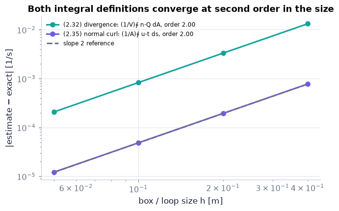

```python
fig, ax = plt.subplots(figsize=(6, 3.8))                                    # log–log
for k, col in (("divergence", COLORS["teal"]), ("curl_component", COLORS["accent"])):   # C15's cached studies
    s = st[k]                                                               # dict(h, err, order)
    lab = "(2.32) divergence: (1/V)∮ n·Q dA" if k == "divergence" else "(2.35) normal curl: (1/A)∮ u·t ds"   # legend text
    ax.loglog(s["h"], s["err"], "o-", color=col, label=f"{lab}, order {s['order']:.2f}")   # error vs size
hr = np.array([min(st["curl_component"]["h"]), max(st["curl_component"]["h"])])   # the h-range of the reference line
ax.loglog(hr, st["curl_component"]["err"].max() * (hr / hr.max())**2, "--", color=COLORS["muted"], label="slope 2 reference")   # ∝ h²
ax.set_xlabel("box / loop size h [m]"); ax.set_ylabel("|estimate − exact| [1/s]"); ax.legend(fontsize=8)   # labels
ax.set_title("Both integral definitions converge at second order in the size")   # the message
plt.show()                                                                  # display
```

**What you see.** Two straight lines of slope 2 on log–log axes, parallel to the dashed reference.

**How to read it.** Halving the box or loop size quarters the error of the integral definitions — the O(Δ²) remainders of D22 step 8 and D26 step 6.

**What would change if…** …a polynomial field of degree ≤ 2: both errors would sit at round-off for every h (the midpoint bookkeeping is exact).

🎮 *The explainer for this theorem* — `stokes_circulation_loop` — is embedded above in C11 (where the curl first bites): use its rectangle mode for Ex. 2.6's four sides and the irrotational-vortex preset for the failing hypothesis.

**What would change if…** the loop enclosed a singular point (the vortex core)? The field is not differentiable inside, Stokes' hypothesis fails, and the circulation is 2πK however small the loop — the "irrotational vortex with circulation" of Ch. 5 and Ch. 6. Everywhere else, $\iint_A(\nabla\times\mathbf u)\cdot\mathbf n\,dA = \oint_C\mathbf u\cdot\mathbf t\,ds$ (2.34) holds to the last digit.

## 2.14 Comma Notation

**What is this section about?** One more shorthand: a comma in the subscript means "partial derivative with respect to the following index".

📝 **Note.** **Comma notation** `N74` — the divergence and curl of C10/C11 in one line each. A comma index behaves like a tensor index (the chain rule, Ch. 1 P49, gives $\partial/\partial x'_j = C_{ij}\,\partial/\partial x_i$ — the vector rule $u'_j = u_iC_{ij}$ (2.8) for ∂), but only in Cartesian coordinates; the book adopts it in §5.6. Watch for the comma: $u_{i,j}$ is the velocity gradient of N52 (C10), $u_{ij}$ would be something else.

$$ A_{,i} \equiv \partial A/\partial x_i, \qquad \nabla\cdot\mathbf u = u_{i,i}, \qquad (\nabla\times\mathbf u)_i = \varepsilon_{ijk}u_{k,j} \qquad \text{(2.36)} $$

```python
print(ch02.expand_indices_str("u_i,i"))                 # (2.36): the comma is parsed as ∂ → Derivative(u_1, x1) + Derivative(u_2, x2) + Derivative(u_3, x3) = (2.23)
print(ch02.comma_to_partial("u_i,j"))                   # the text form: ∂u_i/∂x_j — the velocity gradient of N52
print(ch02.expand_indices_str("eps_ijk u_k,j"))         # the curl in comma notation expands to the three lines of (2.25)
```

```
Derivative(u_1(x1, x2, x3), x1) + Derivative(u_2(x1, x2, x3), x2) + Derivative(u_3(x1, x2, x3), x3)
∂u_i/∂x_j
result_1 = -Derivative(u_2(x1, x2, x3), x3) + Derivative(u_3(x1, x2, x3), x2)
result_2 = Derivative(u_1(x1, x2, x3), x3) - Derivative(u_3(x1, x2, x3), x1)
result_3 = -Derivative(u_1(x1, x2, x3), x2) + Derivative(u_2(x1, x2, x3), x1)
```

**What does the code above do?**

1. `expand_indices_str` reads the comma as a partial derivative and expands the divergence.
2. `comma_to_partial` writes the derivative out in words.
3. The curl in comma notation expands to D12's three components.

*↪ Exercises 2.1–2.20 are not reproduced (the text is the book's). The identities we rely on from them — the inverse rule $x_j = x'_iC_{ji}$ (2.7) and orthogonality (Exercises 2.2, 2.8), the invariants (Exercise 2.9), the tensor examples (Exercise 2.10), isotropy (Exercise 2.11), the dot and cross products (Exercises 2.12–2.14), the ε–δ consequences (Exercises 2.5, 2.7), ∇×∇φ = 0 and ∇·∇×u = 0 (Exercises 2.19, 2.20) — are derived above (D02, D03, D09, D18, D26) and tested in `tests/test_ch02.py`. `S01`*

*↪ Literature: Sommerfeld's tetrahedron argument for $\tau'_{mn} = C_{im}C_{jn}\tau_{ij}$ (2.12) is our D05 + D06; Aris and Prager are the classical tensor references. Not needed to continue. `S02`*

## ✅ What should have clicked

- A repeated index is a loop; the free indices are the shape of the answer (C01).
- C_ij = e_i·e'_j; the columns of C are the new axes; C Cᵀ = I, det C = +1 (C02).
- x' = Cᵀx defines a vector: any triple that fails the test is not one (C03).
- τ_ij: first index the face, second the force; positive out of a + face (C04).
- f = n·τ: the force per area on any plane, from a shrinking tetrahedron (C05).
- τ' = CᵀτC — one C per index — is what 'tensor' means (C06).
- Closed index chains (trace, I₂, det) are frame-independent (C07).
- ε_ijk encodes right-handed perpendicularity; ε ε = δδ − δδ closes vector identities (C08).
- ∇φ is perpendicular to the level sets and points up the steepest slope (C09).
- ∇·u is the total stretching rate — what leaks out per unit volume (C10).
- ∇×u is twice the local spin; a straight shear flow has it (C11).
- G = S + A: stretch plus spin; the vector of A is ½∇×u (the book's R = 2A carries ∇×u); symmetric tensors cannot see A (C12).
- A symmetric tensor has three perpendicular shear-free axes; its eigenvalues bound every normal stress (C13).
- Gauss: derivative inside = normal outside; interior faces cancel (C14).
- Divergence = outflux per unit volume; the Cartesian formula falls out of a box (C15).
- Stokes: circulation round a loop = curl flux through it; curl = circulation per area (C16).

**What later chapters build on**

- Ch. 3: G = S + R from ∂u_i/∂x_j (C12), principal strain rates (C13), vorticity = 2 × angular velocity (C11, D15)
- Ch. 4: Cauchy's equation from ∮ n·τ dA and Gauss (C05, C14), continuity from the shrinking box (C15), dissipation τ:S (C12), the Newtonian stress from δ (C08)
- Ch. 5: vorticity identities with ε–δ (C08), Kelvin's circulation theorem (C16)
- Ch. 13: Coriolis 2Ω × u as ε_ijk (C08), rotating frames as C(t) (C02)

**Not taught here (and where to find it)**

- Exercises (S01) and the literature (S02)
- curvilinear coordinates: Ch. 3 and Appendix B (N72)

← All chapters

← PreviousNext →

Code and explanations: shammun/fluidpy (MIT). The book is not reproduced here; equations are cited by number.